# Equality of Opportunity Seminar Paper

Data Science and Machine Learning 2187 & 2087

Leonard Fidlin, Daniel Jost, Anne Valder

14 1 2021

# **Introduction**

In this part of the seminar paper, we attempt to reproduce the findings of (Brunori and Neidhoefer 2020), but unfortunately we do not have access to the actual EU-SILC data from 2011. Instead we reproduce the findings using the synthetic data provided by the European office of statistics (Eurostat) (https://ec.europa.eu/eurostat/web/microdata/statistics-on-income-and-living-conditions).

```r
library(rpart)
library(rpart.plot)
library(caret)
library(party)
library(partykit) #Ctree
library(ggparty)
library(tidyverse)
library(RColorBrewer)
library(knitr)
library(knitcitations); cleanbib()
cite_options(citation_format = "pandoc", check.entries=FALSE)
library(bibtex)
library(readr)
library(summarytools)
```

# **Data Wrangling**

The original data is not provided as the EU protects the privacy of the original respondents. The idea of the public microdata, is that it allows us to train and write the code using the actual variable names, but not obtaining true results. The EU-SILC public microdata files are fully synthetic and they were simulated using statistical modeling and show the statistical distributions of the original data. The main caveats of this data are, that it cannot be used for statistical inference to the wider population. The results and conclusion obtained from this public microdata are to be taken with a big grain of salt. Luckily, the individual country datasets are grouped in a coherent manner. We use the EU-SILC data from 2011 as it was the survey when additionally there were questions on inter-generational transmission. These were questions about the parents of the respondents. We want to see, whether it is possible using only circumstantial information given about the parents and respondents to predict the income of the respondents.

Outcome Variables i.e. Income: Total Household gross income (HY010), Total Disposable Income (HY020), Dwelling Type (HH010), Housing (HH030).

We first use more variables than ultimately used in the analysis. We use the year of birth to calculate the age, and then exclude everyone older than 60 or younger than 27, as was done in the paper we are referring to. We first included both monthly and annual gross income. But in this cross-country analysis we use annual gross income as our outcome variable.

At first we ran the analysis with the citizenship variable included, but we ultimately decided that it is not really a circumstantial variable as Respondents country of birth would have been. Since it is utltimately possible to obtain a new citizenship.

```r
# setting the data path
data_path ="./SILC_2011"
getwd()
```

```
## [1] "C:/Users/leofi/Desktop/2187-2087_WS2020_Data_Science-Machine_learning/01_Data Science Seminar Paper"
```

```r
# accessing the data
AT_personal_data <- read.csv(file.path(data_path, "AT_2011p_EUSILC.csv"))
AT_household_data <- read.csv(file.path(data_path, "AT_2011h_EUSILC.csv"))

# change the name of the identifier variable
AT_household_data <- AT_household_data %>% rename("PX030" = HB030)

# joining the data
AT_equality_data <- AT_personal_data %>%  left_join(AT_household_data, by = "PX030")

# Renaming important variables for readability of tree
AT_equality_data <- AT_equality_data %>% select(
  PB140, HY010, PB150, PB220A, PT010, PT020, PT030, PT060, PT070, PT090, PT100, PT110, PT120, PT130, PT160, PT150, PT180, PT140, PT170, PT210, PY200G) %>% mutate(
    age = (2011 - PB140), log_income = log(HY010 + 1)
  ) %>% filter(
    age %in% (27:59)
  ) %>% mutate(
    citizenship = factor(PB220A, labels = c(1,2,3))
  ) %>%
  rename(
    "year_of_birth" = PB140,
    "annual_income" = HY010,
    "sex" = PB150,
    "parents_present" = PT010,
    "adults_home" = PT020,
    "children_home" = PT030,
    "father_cob" = PT060,
    "father_cit" = PT070,
    "mother_cob" = PT090,
    "mother_cit" = PT100,
    "father_edu" = PT110,
    "mother_edu" = PT120,
    "father_occup_stat" = PT130,
    "mother_occup_stat" = PT160,
    "father_occup" = PT150,
    "mother_occup" = PT180,
    "father_manag" = PT140,
    "mother_manag" = PT170,
    "tenancy" = PT210,
    "monthly_income" = PY200G)
```

*Summary* We provide the summary statistics for Austria, which we obtained using the ‘dfsummary’ from the package ‘summarytools’. Similar to the 2019 dataset the ‘AT_equality_data’ does contain almost 7000 observations and no missing entries in our outcome variable annual income. However, it does contain many missing values across the observed circumstances. We chose to not exclude those and deal with these missing entries using the ‘na.action = na.omit’ command when doing the statistical analysis.

```r
print(dfSummary(AT_equality_data), method="render")
```

Data Frame Summary

AT_equality_data

**Dimensions**: 6741 x 24  
**Duplicates**: 0

| **No** | **Variable** | **Stats / Values** | **Freqs (% of Valid)** | **Graph** | **Valid** | **Missing** |
| --- | --- | --- | --- | --- | --- | --- |
| 1 | year_of_birth [integer] | Mean (sd) : 1966.9 (9.2) min < med < max: 1952 < 1966 < 1984 IQR (CV) : 16 (0) | 33 distinct values |  | 6741 (100.0%) | 0 (0.0%) |
| 2 | annual_income [integer] | Mean (sd) : 72909.7 (51328.2) min < med < max: 0 < 62595 < 653401 IQR (CV) : 57961 (0.7) | 4077 distinct values |  | 6741 (100.0%) | 0 (0.0%) |
| 3 | sex [integer] | Min : 1 Mean : 1.5 Max : 2 | 1 : 3320 ( 49.3% ) 2 : 3421 ( 50.7% ) |  | 6741 (100.0%) | 0 (0.0%) |
| 4 | PB220A [character] | 1. AT 2. EU 3. Other | 5781 ( 85.8% ) 352 ( 5.2% ) 608 ( 9.0% ) |  | 6741 (100.0%) | 0 (0.0%) |
| 5 | parents_present [integer] | Mean (sd) : 1.3 (0.8) min < med < max: 1 < 1 < 5 IQR (CV) : 0 (0.6) | 1 : 3586 ( 86.5% ) 2 : 75 ( 1.8% ) 3 : 385 ( 9.3% ) 4 : 68 ( 1.6% ) 5 : 31 ( 0.7% ) |  | 4145 (61.5%) | 2596 (38.5%) |
| 6 | adults_home [integer] | Mean (sd) : 2.7 (1.3) min < med < max: 0 < 2 < 12 IQR (CV) : 1 (0.5) | 13 distinct values |  | 4176 (61.9%) | 2565 (38.1%) |
| 7 | children_home [integer] | Mean (sd) : 2.5 (1.6) min < med < max: 1 < 2 < 16 IQR (CV) : 2 (0.6) | 14 distinct values |  | 4164 (61.8%) | 2577 (38.2%) |
| 8 | father_cob [integer] | Mean (sd) : 1.3 (0.7) min < med < max: -1 < 1 < 3 IQR (CV) : 0 (0.5) | -1 : 10 ( 0.2% ) 1 : 3182 ( 78.2% ) 2 : 335 ( 8.2% ) 3 : 542 ( 13.3% ) |  | 4069 (60.4%) | 2672 (39.6%) |
| 9 | father_cit [integer] | Mean (sd) : 1.3 (0.7) min < med < max: -1 < 1 < 3 IQR (CV) : 0 (0.5) | -1 : 8 ( 0.2% ) 1 : 3337 ( 81.1% ) 2 : 224 ( 5.4% ) 3 : 545 ( 13.2% ) |  | 4114 (61.0%) | 2627 (39.0%) |
| 10 | mother_cob [integer] | Mean (sd) : 1.4 (0.7) min < med < max: -1 < 1 < 3 IQR (CV) : 0 (0.5) | -1 : 1 ( 0.0% ) 1 : 3212 ( 77.0% ) 2 : 395 ( 9.5% ) 3 : 564 ( 13.5% ) |  | 4172 (61.9%) | 2569 (38.1%) |
| 11 | mother_cit [integer] | Mean (sd) : 1.3 (0.7) min < med < max: -1 < 1 < 3 IQR (CV) : 0 (0.5) | -1 : 5 ( 0.1% ) 1 : 3323 ( 80.0% ) 2 : 297 ( 7.1% ) 3 : 529 ( 12.7% ) |  | 4154 (61.6%) | 2587 (38.4%) |
| 12 | father_edu [integer] | Mean (sd) : 1.7 (0.8) min < med < max: -1 < 2 < 3 IQR (CV) : 1 (0.5) | -1 : 129 ( 3.1% ) 0 : 24 ( 0.6% ) 1 : 1535 ( 36.8% ) 2 : 1856 ( 44.5% ) 3 : 623 ( 15.0% ) |  | 4167 (61.8%) | 2574 (38.2%) |
| 13 | mother_edu [integer] | Mean (sd) : 1.4 (0.7) min < med < max: -1 < 1 < 3 IQR (CV) : 1 (0.5) | -1 : 60 ( 1.4% ) 0 : 89 ( 2.2% ) 1 : 2271 ( 54.9% ) 2 : 1532 ( 37.0% ) 3 : 187 ( 4.5% ) |  | 4139 (61.4%) | 2602 (38.6%) |
| 14 | father_occup_stat [integer] | Mean (sd) : 1.3 (0.7) min < med < max: -1 < 1 < 6 IQR (CV) : 0 (0.5) | -1 : 31 ( 0.8% ) 1 : 2943 ( 74.8% ) 2 : 869 ( 22.1% ) 3 : 16 ( 0.4% ) 4 : 51 ( 1.3% ) 5 : 3 ( 0.1% ) 6 : 19 ( 0.5% ) |  | 3932 (58.3%) | 2809 (41.7%) |
| 15 | mother_occup_stat [integer] | Mean (sd) : 3 (1.9) min < med < max: -1 < 2 < 6 IQR (CV) : 4 (0.6) | -1 : 18 ( 0.4% ) 1 : 1567 ( 38.3% ) 2 : 665 ( 16.3% ) 3 : 6 ( 0.1% ) 4 : 16 ( 0.4% ) 5 : 1795 ( 43.9% ) 6 : 25 ( 0.6% ) |  | 4092 (60.7%) | 2649 (39.3%) |
| 16 | father_occup [integer] | Mean (sd) : 5.6 (2.3) min < med < max: -1 < 6 < 9 IQR (CV) : 3 (0.4) | 11 distinct values |  | 3813 (56.6%) | 2928 (43.4%) |
| 17 | mother_occup [integer] | Mean (sd) : 5.5 (2.1) min < med < max: -1 < 5 < 9 IQR (CV) : 1 (0.4) | 11 distinct values |  | 2272 (33.7%) | 4469 (66.3%) |
| 18 | father_manag [integer] | Mean (sd) : 1.6 (0.6) min < med < max: -1 < 2 < 2 IQR (CV) : 1 (0.4) | -1 : 72 ( 1.9% ) 1 : 1412 ( 36.5% ) 2 : 2383 ( 61.6% ) |  | 3867 (57.4%) | 2874 (42.6%) |
| 19 | mother_manag [integer] | Mean (sd) : 1.8 (0.5) min < med < max: -1 < 2 < 2 IQR (CV) : 0 (0.3) | -1 : 25 ( 1.1% ) 1 : 391 ( 17.6% ) 2 : 1810 ( 81.3% ) |  | 2226 (33.0%) | 4515 (67.0%) |
| 20 | tenancy [integer] | Mean (sd) : 1.5 (0.7) min < med < max: -1 < 1 < 3 IQR (CV) : 1 (0.5) | -1 : 7 ( 0.2% ) 1 : 2396 ( 58.1% ) 2 : 1205 ( 29.2% ) 3 : 513 ( 12.4% ) |  | 4121 (61.1%) | 2620 (38.9%) |
| 21 | monthly_income [integer] | Mean (sd) : 624.1 (280.8) min < med < max: 1 < 851 < 851 IQR (CV) : 495 (0.5) | 651 distinct values |  | 6741 (100.0%) | 0 (0.0%) |
| 22 | age [numeric] | Mean (sd) : 44.1 (9.2) min < med < max: 27 < 45 < 59 IQR (CV) : 16 (0.2) | 33 distinct values |  | 6741 (100.0%) | 0 (0.0%) |
| 23 | log_income [numeric] | Mean (sd) : 10.9 (1.1) min < med < max: 0 < 11 < 13.4 IQR (CV) : 0.9 (0.1) | 4077 distinct values |  | 6741 (100.0%) | 0 (0.0%) |
| 24 | citizenship [factor] | 1. 1 2. 2 3. 3 | 5781 ( 85.8% ) 352 ( 5.2% ) 608 ( 9.0% ) |  | 6741 (100.0%) | 0 (0.0%) |

Generated by summarytools 0.9.8 ([R](https://www.r-project.org/) version 4.0.3)  
2021-02-14

```r
# Here we repeat the Data Wrangling steps for other EU Member States
# France
FR_personal_data <- read.csv(file.path(data_path, "FR_2011p_EUSILC.csv"))
FR_household_data <- read.csv(file.path(data_path, "FR_2011h_EUSILC.csv"))
FR_household_data <- FR_household_data %>% rename("PX030" = HB030)
FR_equality_data <- FR_personal_data %>%  left_join(FR_household_data, by = "PX030")

FR_equality_data <- FR_equality_data %>% select(
  PB140, HY010, PB150, PB220A, PT010, PT020, PT030, PT060, PT070, PT090, PT100, PT110, PT120, PT130, PT160, PT150, PT180, PT140, PT170, PT210, PY200G) %>% mutate(
    age = (2011 - PB140), log_income = log(HY010 + 1)
  ) %>% filter(
    age %in% (27:59)
  ) %>% mutate(
    citizenship = factor(PB220A, labels = c(1,2,3))
  ) %>%
  rename(
    "year_of_birth" = PB140,
    "annual_income" = HY010,
    "sex" = PB150,
    "parents_present" = PT010,
    "adults_home" = PT020,
    "children_home" = PT030,
    "father_cob" = PT060,
    "father_cit" = PT070,
    "mother_cob" = PT090,
    "mother_cit" = PT100,
    "father_edu" = PT110,
    "mother_edu" = PT120,
    "father_occup_stat" = PT130,
    "mother_occup_stat" = PT160,
    "father_occup" = PT150,
    "mother_occup" = PT180,
    "father_manag" = PT140,
    "mother_manag" = PT170,
    "tenancy" = PT210,
    "monthly_income" = PY200G)
# Denmark
DK_personal_data <- read.csv(file.path(data_path, "DK_2011p_EUSILC.csv"))
DK_household_data <- read.csv(file.path(data_path, "DK_2011h_EUSILC.csv"))
DK_household_data <- DK_household_data %>% rename("PX030" = HB030)
DK_equality_data <- DK_personal_data %>%  left_join(DK_household_data, by = "PX030")

DK_equality_data <- DK_equality_data %>% select(
  PB140, HY010, PB150, PB220A, PT010, PT020, PT030, PT060, PT070, PT090, PT100, PT110, PT120, PT130, PT160, PT150, PT180, PT140, PT170, PT210, PY200G) %>% mutate(
    age = (2011 - PB140), log_income = log(HY010 + 1)
  ) %>% filter(
    age %in% (27:59)
  ) %>% mutate(
    citizenship = factor(PB220A, labels = c(1,2,3))
  ) %>%
  rename(
    "year_of_birth" = PB140,
    "annual_income" = HY010,
    "sex" = PB150,
    "parents_present" = PT010,
    "adults_home" = PT020,
    "children_home" = PT030,
    "father_cob" = PT060,
    "father_cit" = PT070,
    "mother_cob" = PT090,
    "mother_cit" = PT100,
    "father_edu" = PT110,
    "mother_edu" = PT120,
    "father_occup_stat" = PT130,
    "mother_occup_stat" = PT160,
    "father_occup" = PT150,
    "mother_occup" = PT180,
    "father_manag" = PT140,
    "mother_manag" = PT170,
    "tenancy" = PT210,
    "monthly_income" = PY200G)
# Spain
ES_personal_data <- read.csv(file.path(data_path, "ES_2011p_EUSILC.csv"))
ES_household_data <- read.csv(file.path(data_path, "ES_2011h_EUSILC.csv"))
ES_household_data <- ES_household_data %>% rename("PX030" = HB030)
ES_equality_data <- ES_personal_data %>%  left_join(ES_household_data, by = "PX030")

ES_equality_data <- ES_equality_data %>% select(
  PB140, HY010, PB150, PB220A, PT010, PT020, PT030, PT060, PT070, PT090, PT100, PT110, PT120, PT130, PT160, PT150, PT180, PT140, PT170, PT210, PY200G) %>% mutate(
    age = (2011 - PB140), log_income = log(HY010 + 1)
  ) %>% filter(
    age %in% (27:59)
  ) %>% mutate(
    citizenship = factor(PB220A, labels = c(1,2,3))
  ) %>%
  rename(
    "year_of_birth" = PB140,
    "annual_income" = HY010,
    "sex" = PB150,
    "parents_present" = PT010,
    "adults_home" = PT020,
    "children_home" = PT030,
    "father_cob" = PT060,
    "father_cit" = PT070,
    "mother_cob" = PT090,
    "mother_cit" = PT100,
    "father_edu" = PT110,
    "mother_edu" = PT120,
    "father_occup_stat" = PT130,
    "mother_occup_stat" = PT160,
    "father_occup" = PT150,
    "mother_occup" = PT180,
    "father_manag" = PT140,
    "mother_manag" = PT170,
    "tenancy" = PT210,
    "monthly_income" = PY200G)
# Finland
FI_personal_data <- read.csv(file.path(data_path, "FI_2011p_EUSILC.csv"))
FI_household_data <- read.csv(file.path(data_path, "FI_2011h_EUSILC.csv"))
FI_household_data <- FI_household_data %>% rename("PX030" = HB030)
FI_equality_data <- FI_personal_data %>%  left_join(FI_household_data, by = "PX030")

FI_equality_data <- FI_equality_data %>% select(
  PB140, HY010, PB150, PB220A, PT010, PT020, PT030, PT060, PT070, PT090, PT100, PT110, PT120, PT130, PT160, PT150, PT180, PT140, PT170, PT210, PY200G) %>% mutate(
    age = (2011 - PB140), log_income = log(HY010 + 1)
  ) %>% filter(
    age %in% (27:59)
  ) %>% mutate(
    citizenship = factor(PB220A, labels = c(1,2,3))
  ) %>%
  rename(
    "year_of_birth" = PB140,
    "annual_income" = HY010,
    "sex" = PB150,
    "parents_present" = PT010,
    "adults_home" = PT020,
    "children_home" = PT030,
    "father_cob" = PT060,
    "father_cit" = PT070,
    "mother_cob" = PT090,
    "mother_cit" = PT100,
    "father_edu" = PT110,
    "mother_edu" = PT120,
    "father_occup_stat" = PT130,
    "mother_occup_stat" = PT160,
    "father_occup" = PT150,
    "mother_occup" = PT180,
    "father_manag" = PT140,
    "mother_manag" = PT170,
    "tenancy" = PT210,
    "monthly_income" = PY200G)
# Italy
IT_personal_data <- read.csv(file.path(data_path, "IT_2011p_EUSILC.csv"))
IT_household_data <- read.csv(file.path(data_path, "IT_2011h_EUSILC.csv"))
IT_household_data <- IT_household_data %>% rename("PX030" = HB030)
IT_equality_data <- IT_personal_data %>%  left_join(IT_household_data, by = "PX030")

IT_equality_data <- IT_equality_data %>% select(
  PB140, HY010, PB150, PB220A, PT010, PT020, PT030, PT060, PT070, PT090, PT100, PT110, PT120, PT130, PT160, PT150, PT180, PT140, PT170, PT210, PY200G) %>% mutate(
    age = (2011 - PB140), log_income = log(HY010 + 1)
  ) %>% filter(
    age %in% (27:59)
  ) %>% mutate(
    citizenship = factor(PB220A, labels = c(1,2,3))
  ) %>%
  rename(
    "year_of_birth" = PB140,
    "annual_income" = HY010,
    "sex" = PB150,
    "parents_present" = PT010,
    "adults_home" = PT020,
    "children_home" = PT030,
    "father_cob" = PT060,
    "father_cit" = PT070,
    "mother_cob" = PT090,
    "mother_cit" = PT100,
    "father_edu" = PT110,
    "mother_edu" = PT120,
    "father_occup_stat" = PT130,
    "mother_occup_stat" = PT160,
    "father_occup" = PT150,
    "mother_occup" = PT180,
    "father_manag" = PT140,
    "mother_manag" = PT170,
    "tenancy" = PT210,
    "monthly_income" = PY200G)
# # Bulgaria
# BG_personal_data <- read.csv(file.path(data_path, "BG_2011p_EUSILC.csv"))
# BG_household_data <- read.csv(file.path(data_path, "BG_2011h_EUSILC.csv"))
# BG_household_data <- BG_household_data %>% rename("PX030" = HB030)
# BG_equality_data <- BG_personal_data %>%  left_join(BG_household_data, by = "PX030")
#
# BG_equality_data <- BG_equality_data %>% select(
#   PB140, HY010, PB150, PB220A, PT010, PT020, PT030, PT060, PT070, PT090, PT100, PT110, PT120, PT130, PT160, PT150, PT180, PT140, PT170, PT210, PY200G) %>% mutate(
#     age = (2011 - PB140), log_income = log(HY010 + 1)
#   ) %>% filter(
#     age %in% (27:59)
#   ) %>% mutate(
#     citizenship = factor(PB220A, labels = c(1,2,3))
#   ) %>%
#   rename(
#     "year_of_birth" = PB140,
#     "annual_income" = HY010,
#     "sex" = PB150,
#     "parents_present" = PT010,
#     "adults_home" = PT020,
#     "children_home" = PT030,
#     "father_cob" = PT060,
#     "father_cit" = PT070,
#     "mother_cob" = PT090,
#     "mother_cit" = PT100,
#     "father_edu" = PT110,
#     "mother_edu" = PT120,
#     "father_occup_stat" = PT130,
#     "mother_occup_stat" = PT160,
#     "father_occup" = PT150,
#     "mother_occup" = PT180,
#     "father_manag" = PT140,
#     "mother_manag" = PT170,
#     "tenancy" = PT210,
#     "monthly_income" = PY200G)
# Latvia
LV_personal_data <- read.csv(file.path(data_path, "LV_2011p_EUSILC.csv"))
LV_household_data <- read.csv(file.path(data_path, "LV_2011h_EUSILC.csv"))
LV_household_data <- LV_household_data %>% rename("PX030" = HB030)
LV_equality_data <- LV_personal_data %>%  left_join(LV_household_data, by = "PX030")

LV_equality_data <- LV_equality_data %>% select(
  PB140, HY010, PB150, PB220A, PT010, PT020, PT030, PT060, PT070, PT090, PT100, PT110, PT120, PT130, PT160, PT150, PT180, PT140, PT170, PT210, PY200G) %>% mutate(
    age = (2011 - PB140), log_income = log(HY010 + 1)
  ) %>% filter(
    age %in% (27:59)
  ) %>% mutate(
    citizenship = factor(PB220A, labels = c(1,2,3))
  ) %>%
  rename(
    "year_of_birth" = PB140,
    "annual_income" = HY010,
    "sex" = PB150,
    "parents_present" = PT010,
    "adults_home" = PT020,
    "children_home" = PT030,
    "father_cob" = PT060,
    "father_cit" = PT070,
    "mother_cob" = PT090,
    "mother_cit" = PT100,
    "father_edu" = PT110,
    "mother_edu" = PT120,
    "father_occup_stat" = PT130,
    "mother_occup_stat" = PT160,
    "father_occup" = PT150,
    "mother_occup" = PT180,
    "father_manag" = PT140,
    "mother_manag" = PT170,
    "tenancy" = PT210,
    "monthly_income" = PY200G)
```

```r
print(dfSummary(FR_equality_data), method="render")
```

Data Frame Summary

FR_equality_data

**Dimensions**: 11013 x 24  
**Duplicates**: 0

| **No** | **Variable** | **Stats / Values** | **Freqs (% of Valid)** | **Graph** | **Valid** | **Missing** |
| --- | --- | --- | --- | --- | --- | --- |
| 1 | year_of_birth [integer] | Mean (sd) : 1967.9 (9.4) min < med < max: 1952 < 1968 < 1984 IQR (CV) : 16 (0) | 33 distinct values |  | 11013 (100.0%) | 0 (0.0%) |
| 2 | annual_income [integer] | Mean (sd) : 59673.4 (48605.8) min < med < max: 0 < 51111 < 1284688 IQR (CV) : 40114 (0.8) | 6743 distinct values |  | 11013 (100.0%) | 0 (0.0%) |
| 3 | sex [integer] | Min : 1 Mean : 1.5 Max : 2 | 1 : 5372 ( 48.8% ) 2 : 5641 ( 51.2% ) |  | 11013 (100.0%) | 0 (0.0%) |
| 4 | PB220A [character] | 1. EU 2. FR 3. Other | 223 ( 2.0% ) 10328 ( 93.8% ) 462 ( 4.2% ) |  | 11013 (100.0%) | 0 (0.0%) |
| 5 | parents_present [integer] | Mean (sd) : 1.4 (0.9) min < med < max: 1 < 1 < 5 IQR (CV) : 0 (0.6) | 1 : 5531 ( 82.8% ) 2 : 124 ( 1.9% ) 3 : 825 ( 12.4% ) 4 : 121 ( 1.8% ) 5 : 78 ( 1.2% ) |  | 6679 (60.6%) | 4334 (39.4%) |
| 6 | adults_home [integer] | Mean (sd) : 2.4 (1.2) min < med < max: 0 < 2 < 20 IQR (CV) : 1 (0.5) | 15 distinct values |  | 6560 (59.6%) | 4453 (40.4%) |
| 7 | children_home [integer] | Mean (sd) : 1.6 (1.5) min < med < max: 0 < 1 < 13 IQR (CV) : 1 (1) | 13 distinct values |  | 6526 (59.3%) | 4487 (40.7%) |
| 8 | father_cob [integer] | Mean (sd) : 1.4 (1) min < med < max: -1 < 1 < 4 IQR (CV) : 0 (0.7) | -1 : 5 ( 0.1% ) 1 : 5209 ( 80.7% ) 2 : 491 ( 7.6% ) 3 : 33 ( 0.5% ) 4 : 714 ( 11.1% ) |  | 6452 (58.6%) | 4561 (41.4%) |
| 9 | father_cit [integer] | Mean (sd) : 1.3 (0.8) min < med < max: -1 < 1 < 4 IQR (CV) : 0 (0.6) | -1 : 27 ( 0.4% ) 1 : 5682 ( 87.0% ) 2 : 373 ( 5.7% ) 3 : 22 ( 0.3% ) 4 : 426 ( 6.5% ) |  | 6530 (59.3%) | 4483 (40.7%) |
| 10 | mother_cob [integer] | Mean (sd) : 1.4 (0.9) min < med < max: 1 < 1 < 4 IQR (CV) : 0 (0.7) | 1 : 5417 ( 82.5% ) 2 : 462 ( 7.0% ) 3 : 30 ( 0.5% ) 4 : 660 ( 10.0% ) |  | 6569 (59.6%) | 4444 (40.4%) |
| 11 | mother_cit [integer] | Mean (sd) : 1.2 (0.8) min < med < max: -1 < 1 < 4 IQR (CV) : 0 (0.6) | -1 : 23 ( 0.3% ) 1 : 5941 ( 88.4% ) 2 : 306 ( 4.6% ) 3 : 24 ( 0.4% ) 4 : 428 ( 6.4% ) |  | 6722 (61.0%) | 4291 (39.0%) |
| 12 | father_edu [integer] | Mean (sd) : 1.1 (1) min < med < max: -1 < 1 < 3 IQR (CV) : 0 (0.9) | -1 : 554 ( 8.4% ) 0 : 242 ( 3.7% ) 1 : 4480 ( 68.1% ) 2 : 554 ( 8.4% ) 3 : 753 ( 11.4% ) |  | 6583 (59.8%) | 4430 (40.2%) |
| 13 | mother_edu [integer] | Mean (sd) : 1.1 (0.8) min < med < max: -1 < 1 < 3 IQR (CV) : 0 (0.8) | -1 : 365 ( 5.5% ) 0 : 339 ( 5.1% ) 1 : 4750 ( 72.0% ) 2 : 611 ( 9.3% ) 3 : 535 ( 8.1% ) |  | 6600 (59.9%) | 4413 (40.1%) |
| 14 | father_occup_stat [integer] | Mean (sd) : 1.2 (0.8) min < med < max: -1 < 1 < 6 IQR (CV) : 0 (0.6) | -1 : 134 ( 2.1% ) 1 : 4824 ( 77.1% ) 2 : 1137 ( 18.2% ) 3 : 42 ( 0.7% ) 4 : 37 ( 0.6% ) 5 : 5 ( 0.1% ) 6 : 79 ( 1.3% ) |  | 6258 (56.8%) | 4755 (43.2%) |
| 15 | mother_occup_stat [integer] | Mean (sd) : 2.8 (2) min < med < max: -1 < 2 < 6 IQR (CV) : 4 (0.7) | -1 : 93 ( 1.4% ) 1 : 3134 ( 48.3% ) 2 : 526 ( 8.1% ) 3 : 13 ( 0.2% ) 4 : 10 ( 0.2% ) 5 : 2612 ( 40.2% ) 6 : 107 ( 1.6% ) |  | 6495 (59.0%) | 4518 (41.0%) |
| 16 | father_occup [integer] | Mean (sd) : 5.3 (3) min < med < max: -1 < 6 < 9 IQR (CV) : 5 (0.6) | 11 distinct values |  | 6061 (55.0%) | 4952 (45.0%) |
| 17 | mother_occup [integer] | Mean (sd) : 5.1 (2.5) min < med < max: -1 < 5 < 9 IQR (CV) : 3 (0.5) | 11 distinct values |  | 3795 (34.5%) | 7218 (65.5%) |
| 18 | father_manag [integer] | Mean (sd) : 1.5 (0.8) min < med < max: -1 < 2 < 2 IQR (CV) : 1 (0.5) | -1 : 356 ( 5.8% ) 1 : 2223 ( 36.0% ) 2 : 3591 ( 58.2% ) |  | 6170 (56.0%) | 4843 (44.0%) |
| 19 | mother_manag [integer] | Mean (sd) : 1.8 (0.6) min < med < max: -1 < 2 < 2 IQR (CV) : 0 (0.4) | -1 : 142 ( 3.8% ) 1 : 494 ( 13.1% ) 2 : 3121 ( 83.1% ) |  | 3757 (34.1%) | 7256 (65.9%) |
| 20 | tenancy [integer] | Mean (sd) : 1.4 (0.6) min < med < max: -1 < 1 < 3 IQR (CV) : 1 (0.5) | -1 : 100 ( 1.5% ) 1 : 4230 ( 64.0% ) 2 : 2009 ( 30.4% ) 3 : 269 ( 4.1% ) |  | 6608 (60.0%) | 4405 (40.0%) |
| 21 | monthly_income [integer] | 1 distinct value | 1 : 11013 ( 100.0% ) |  | 11013 (100.0%) | 0 (0.0%) |
| 22 | age [numeric] | Mean (sd) : 43.1 (9.4) min < med < max: 27 < 43 < 59 IQR (CV) : 16 (0.2) | 33 distinct values |  | 11013 (100.0%) | 0 (0.0%) |
| 23 | log_income [numeric] | Mean (sd) : 10.7 (0.9) min < med < max: 0 < 10.8 < 14.1 IQR (CV) : 0.8 (0.1) | 6743 distinct values |  | 11013 (100.0%) | 0 (0.0%) |
| 24 | citizenship [factor] | 1. 1 2. 2 3. 3 | 223 ( 2.0% ) 10328 ( 93.8% ) 462 ( 4.2% ) |  | 11013 (100.0%) | 0 (0.0%) |

Generated by summarytools 0.9.8 ([R](https://www.r-project.org/) version 4.0.3)  
2021-02-14

```r
print(dfSummary(DK_equality_data), method="render") #We have maybe too many missing values for Denmark
```

Data Frame Summary

DK_equality_data

**Dimensions**: 4536 x 24  
**Duplicates**: 0

| **No** | **Variable** | **Stats / Values** | **Freqs (% of Valid)** | **Graph** | **Valid** | **Missing** |
| --- | --- | --- | --- | --- | --- | --- |
| 1 | year_of_birth [integer] | Mean (sd) : 1967.5 (9.2) min < med < max: 1952 < 1967 < 1984 IQR (CV) : 15 (0) | 33 distinct values |  | 4536 (100.0%) | 0 (0.0%) |
| 2 | annual_income [integer] | Mean (sd) : 82526 (48369.5) min < med < max: -112975 < 77951 < 532044 IQR (CV) : 55764.5 (0.6) | 2983 distinct values |  | 4536 (100.0%) | 0 (0.0%) |
| 3 | sex [integer] | Min : 1 Mean : 1.5 Max : 2 | 1 : 2301 ( 50.7% ) 2 : 2235 ( 49.3% ) |  | 4536 (100.0%) | 0 (0.0%) |
| 4 | PB220A [character] | 1. DK 2. EU 3. Other | 4318 ( 95.2% ) 100 ( 2.2% ) 118 ( 2.6% ) |  | 4536 (100.0%) | 0 (0.0%) |
| 5 | parents_present [integer] | Mean (sd) : 1.4 (0.8) min < med < max: 1 < 1 < 5 IQR (CV) : 0 (0.6) | 1 : 1478 ( 82.8% ) 2 : 43 ( 2.4% ) 3 : 228 ( 12.8% ) 4 : 15 ( 0.8% ) 5 : 22 ( 1.2% ) |  | 1786 (39.4%) | 2750 (60.6%) |
| 6 | adults_home [integer] | Mean (sd) : 2.2 (0.8) min < med < max: 1 < 2 < 8 IQR (CV) : 0 (0.3) | 1 : 176 ( 9.5% ) 2 : 1289 ( 69.5% ) 3 : 287 ( 15.5% ) 4 : 77 ( 4.2% ) 5 : 12 ( 0.6% ) 6 : 7 ( 0.4% ) 7 : 4 ( 0.2% ) 8 : 2 ( 0.1% ) |  | 1854 (40.9%) | 2682 (59.1%) |
| 7 | children_home [integer] | Mean (sd) : 2.1 (1.1) min < med < max: 1 < 2 < 9 IQR (CV) : 2 (0.5) | 1 : 587 ( 32.0% ) 2 : 714 ( 39.0% ) 3 : 355 ( 19.4% ) 4 : 112 ( 6.1% ) 5 : 31 ( 1.7% ) 6 : 22 ( 1.2% ) 7 : 6 ( 0.3% ) 8 : 5 ( 0.3% ) 9 : 1 ( 0.1% ) |  | 1833 (40.4%) | 2703 (59.6%) |
| 8 | father_cob [integer] | Mean (sd) : 1.1 (0.5) min < med < max: 1 < 1 < 4 IQR (CV) : 0 (0.4) | 1 : 1719 ( 94.8% ) 2 : 47 ( 2.6% ) 3 : 11 ( 0.6% ) 4 : 37 ( 2.0% ) |  | 1814 (40.0%) | 2722 (60.0%) |
| 9 | father_cit [integer] | Mean (sd) : 1 (0.2) min < med < max: 1 < 1 < 3 IQR (CV) : 0 (0.2) | 1 : 1715 ( 97.3% ) 2 : 31 ( 1.8% ) 3 : 16 ( 0.9% ) |  | 1762 (38.8%) | 2774 (61.2%) |
| 10 | mother_cob [integer] | Mean (sd) : 1.1 (0.6) min < med < max: 1 < 1 < 4 IQR (CV) : 0 (0.5) | 1 : 1708 ( 92.5% ) 2 : 62 ( 3.4% ) 3 : 21 ( 1.1% ) 4 : 56 ( 3.0% ) |  | 1847 (40.7%) | 2689 (59.3%) |
| 11 | mother_cit [integer] | Mean (sd) : 1.1 (0.5) min < med < max: 1 < 1 < 4 IQR (CV) : 0 (0.5) | 1 : 1763 ( 94.6% ) 2 : 35 ( 1.9% ) 3 : 14 ( 0.8% ) 4 : 51 ( 2.7% ) |  | 1863 (41.1%) | 2673 (58.9%) |
| 12 | father_edu [integer] | Mean (sd) : 1.9 (0.8) min < med < max: 1 < 2 < 3 IQR (CV) : 2 (0.4) | 1 : 522 ( 33.4% ) 2 : 650 ( 41.5% ) 3 : 393 ( 25.1% ) |  | 1565 (34.5%) | 2971 (65.5%) |
| 13 | mother_edu [integer] | Mean (sd) : 1.7 (0.8) min < med < max: 1 < 2 < 3 IQR (CV) : 1 (0.5) | 1 : 836 ( 47.5% ) 2 : 551 ( 31.3% ) 3 : 373 ( 21.2% ) |  | 1760 (38.8%) | 2776 (61.2%) |
| 14 | father_occup_stat [integer] | Mean (sd) : 1.3 (0.6) min < med < max: 1 < 1 < 6 IQR (CV) : 1 (0.4) | 1 : 1125 ( 72.1% ) 2 : 403 ( 25.8% ) 3 : 9 ( 0.6% ) 4 : 20 ( 1.3% ) 5 : 1 ( 0.1% ) 6 : 2 ( 0.1% ) |  | 1560 (34.4%) | 2976 (65.6%) |
| 15 | mother_occup_stat [integer] | Mean (sd) : 2.2 (1.8) min < med < max: 1 < 1 < 6 IQR (CV) : 4 (0.8) | 1 : 1105 ( 64.3% ) 2 : 117 ( 6.8% ) 3 : 9 ( 0.5% ) 4 : 29 ( 1.7% ) 5 : 445 ( 25.9% ) 6 : 14 ( 0.8% ) |  | 1719 (37.9%) | 2817 (62.1%) |
| 16 | father_occup [integer] | Mean (sd) : 5 (2.4) min < med < max: 1 < 6 < 9 IQR (CV) : 5 (0.5) | 1 : 183 ( 12.3% ) 2 : 190 ( 12.8% ) 3 : 123 ( 8.3% ) 4 : 51 ( 3.4% ) 5 : 125 ( 8.4% ) 6 : 238 ( 16.0% ) 7 : 448 ( 30.1% ) 8 : 110 ( 7.4% ) 9 : 19 ( 1.3% ) |  | 1487 (32.8%) | 3049 (67.2%) |
| 17 | mother_occup [integer] | Mean (sd) : 4.1 (1.6) min < med < max: 1 < 4 < 9 IQR (CV) : 2 (0.4) | 1 : 34 ( 2.9% ) 2 : 201 ( 17.4% ) 3 : 172 ( 14.9% ) 4 : 219 ( 18.9% ) 5 : 366 ( 31.7% ) 6 : 56 ( 4.8% ) 7 : 75 ( 6.5% ) 8 : 32 ( 2.8% ) 9 : 1 ( 0.1% ) |  | 1156 (25.5%) | 3380 (74.5%) |
| 18 | father_manag [integer] | Min : 1 Mean : 1.5 Max : 2 | 1 : 697 ( 46.1% ) 2 : 814 ( 53.9% ) |  | 1511 (33.3%) | 3025 (66.7%) |
| 19 | mother_manag [integer] | Min : 1 Mean : 1.8 Max : 2 | 1 : 228 ( 18.8% ) 2 : 987 ( 81.2% ) |  | 1215 (26.8%) | 3321 (73.2%) |
| 20 | tenancy [integer] | Mean (sd) : 1.3 (0.5) min < med < max: 1 < 1 < 3 IQR (CV) : 0 (0.4) | 1 : 1359 ( 75.3% ) 2 : 433 ( 24.0% ) 3 : 13 ( 0.7% ) |  | 1805 (39.8%) | 2731 (60.2%) |
| 21 | monthly_income [integer] | 1 distinct value | 1 : 4536 ( 100.0% ) |  | 4536 (100.0%) | 0 (0.0%) |
| 22 | age [numeric] | Mean (sd) : 43.5 (9.2) min < med < max: 27 < 44 < 59 IQR (CV) : 15 (0.2) | 33 distinct values |  | 4536 (100.0%) | 0 (0.0%) |
| 23 | log_income [numeric] | Mean (sd) : 11.2 (0.7) min < med < max: 3.5 < 11.3 < 13.2 IQR (CV) : 0.7 (0.1) | 2956 distinct values |  | 4502 (99.3%) | 34 (0.7%) |
| 24 | citizenship [factor] | 1. 1 2. 2 3. 3 | 4318 ( 95.2% ) 100 ( 2.2% ) 118 ( 2.6% ) |  | 4536 (100.0%) | 0 (0.0%) |

Generated by summarytools 0.9.8 ([R](https://www.r-project.org/) version 4.0.3)  
2021-02-14

```r
print(dfSummary(ES_equality_data), method="render")
```

Data Frame Summary

ES_equality_data

**Dimensions**: 17160 x 24  
**Duplicates**: 0

| **No** | **Variable** | **Stats / Values** | **Freqs (% of Valid)** | **Graph** | **Valid** | **Missing** |
| --- | --- | --- | --- | --- | --- | --- |
| 1 | year_of_birth [integer] | Mean (sd) : 1968.4 (9) min < med < max: 1952 < 1969 < 1984 IQR (CV) : 15 (0) | 33 distinct values |  | 17160 (100.0%) | 0 (0.0%) |
| 2 | annual_income [integer] | Mean (sd) : 42864.5 (32836.6) min < med < max: -61984 < 36351 < 533691 IQR (CV) : 35266.2 (0.8) | 9103 distinct values |  | 17160 (100.0%) | 0 (0.0%) |
| 3 | sex [integer] | Min : 1 Mean : 1.5 Max : 2 | 1 : 8701 ( 50.7% ) 2 : 8459 ( 49.3% ) |  | 17160 (100.0%) | 0 (0.0%) |
| 4 | PB220A [character] | 1. ES 2. EU 3. Other | 14628 ( 85.2% ) 777 ( 4.5% ) 1755 ( 10.2% ) |  | 17160 (100.0%) | 0 (0.0%) |
| 5 | parents_present [integer] | Mean (sd) : 1.2 (0.8) min < med < max: 1 < 1 < 5 IQR (CV) : 0 (0.6) | 1 : 10052 ( 89.3% ) 2 : 145 ( 1.3% ) 3 : 617 ( 5.5% ) 4 : 369 ( 3.3% ) 5 : 79 ( 0.7% ) |  | 11262 (65.6%) | 5898 (34.4%) |
| 6 | adults_home [integer] | Mean (sd) : 2.8 (1.3) min < med < max: 0 < 2 < 14 IQR (CV) : 2 (0.5) | 15 distinct values |  | 11170 (65.1%) | 5990 (34.9%) |
| 7 | children_home [integer] | Mean (sd) : 2.4 (1.4) min < med < max: 1 < 2 < 12 IQR (CV) : 2 (0.6) | 12 distinct values |  | 11023 (64.2%) | 6137 (35.8%) |
| 8 | father_cob [integer] | Mean (sd) : 1.4 (0.9) min < med < max: -1 < 1 < 4 IQR (CV) : 0 (0.7) | -1 : 73 ( 0.6% ) 1 : 9477 ( 83.8% ) 2 : 534 ( 4.7% ) 3 : 65 ( 0.6% ) 4 : 1158 ( 10.2% ) |  | 11307 (65.9%) | 5853 (34.1%) |
| 9 | father_cit [integer] | Mean (sd) : 1.3 (0.9) min < med < max: -1 < 1 < 4 IQR (CV) : 0 (0.7) | -1 : 16 ( 0.1% ) 1 : 9534 ( 85.6% ) 2 : 493 ( 4.4% ) 3 : 52 ( 0.5% ) 4 : 1040 ( 9.3% ) |  | 11135 (64.9%) | 6025 (35.1%) |
| 10 | mother_cob [integer] | Mean (sd) : 1.3 (0.9) min < med < max: -1 < 1 < 4 IQR (CV) : 0 (0.7) | -1 : 57 ( 0.5% ) 1 : 9461 ( 85.0% ) 2 : 452 ( 4.1% ) 3 : 56 ( 0.5% ) 4 : 1107 ( 9.9% ) |  | 11133 (64.9%) | 6027 (35.1%) |
| 11 | mother_cit [integer] | Mean (sd) : 1.3 (0.9) min < med < max: -1 < 1 < 4 IQR (CV) : 0 (0.7) | -1 : 35 ( 0.3% ) 1 : 9628 ( 85.7% ) 2 : 505 ( 4.5% ) 3 : 48 ( 0.4% ) 4 : 1023 ( 9.1% ) |  | 11239 (65.5%) | 5921 (34.5%) |
| 12 | father_edu [integer] | Mean (sd) : 1.2 (0.8) min < med < max: -1 < 1 < 3 IQR (CV) : 0 (0.7) | -1 : 375 ( 3.3% ) 0 : 504 ( 4.5% ) 1 : 8447 ( 75.1% ) 2 : 848 ( 7.5% ) 3 : 1073 ( 9.5% ) |  | 11247 (65.5%) | 5913 (34.5%) |
| 13 | mother_edu [integer] | Mean (sd) : 1 (0.6) min < med < max: -1 < 1 < 3 IQR (CV) : 0 (0.6) | -1 : 277 ( 2.5% ) 0 : 769 ( 6.8% ) 1 : 9027 ( 80.0% ) 2 : 681 ( 6.0% ) 3 : 534 ( 4.7% ) |  | 11288 (65.8%) | 5872 (34.2%) |
| 14 | father_occup_stat [integer] | Mean (sd) : 1.3 (0.7) min < med < max: -1 < 1 < 6 IQR (CV) : 0 (0.5) | -1 : 60 ( 0.6% ) 1 : 7924 ( 74.5% ) 2 : 2359 ( 22.2% ) 3 : 42 ( 0.4% ) 4 : 173 ( 1.6% ) 5 : 13 ( 0.1% ) 6 : 65 ( 0.6% ) |  | 10636 (62.0%) | 6524 (38.0%) |
| 15 | mother_occup_stat [integer] | Mean (sd) : 3.9 (1.7) min < med < max: -1 < 5 < 6 IQR (CV) : 3 (0.4) | -1 : 54 ( 0.5% ) 1 : 2263 ( 20.7% ) 2 : 764 ( 7.0% ) 3 : 21 ( 0.2% ) 4 : 27 ( 0.2% ) 5 : 7741 ( 70.9% ) 6 : 54 ( 0.5% ) |  | 10924 (63.7%) | 6236 (36.3%) |
| 16 | father_occup [integer] | Mean (sd) : 5.6 (2.6) min < med < max: -1 < 6 < 9 IQR (CV) : 4 (0.5) | 11 distinct values |  | 10357 (60.4%) | 6803 (39.6%) |
| 17 | mother_occup [integer] | Mean (sd) : 5.7 (2.6) min < med < max: -1 < 5 < 9 IQR (CV) : 5 (0.5) | -1 : 36 ( 1.2% ) 1 : 132 ( 4.3% ) 2 : 339 ( 11.1% ) 3 : 129 ( 4.2% ) 4 : 283 ( 9.3% ) 5 : 675 ( 22.2% ) 6 : 295 ( 9.7% ) 7 : 220 ( 7.2% ) 8 : 123 ( 4.0% ) 9 : 810 ( 26.6% ) |  | 3042 (17.7%) | 14118 (82.3%) |
| 18 | father_manag [integer] | Mean (sd) : 1.8 (0.4) min < med < max: -1 < 2 < 2 IQR (CV) : 0 (0.2) | -1 : 20 ( 0.2% ) 1 : 2235 ( 21.5% ) 2 : 8125 ( 78.3% ) |  | 10380 (60.5%) | 6780 (39.5%) |
| 19 | mother_manag [integer] | Mean (sd) : 1.9 (0.3) min < med < max: -1 < 2 < 2 IQR (CV) : 0 (0.2) | -1 : 2 ( 0.1% ) 1 : 377 ( 12.5% ) 2 : 2648 ( 87.5% ) |  | 3027 (17.6%) | 14133 (82.4%) |
| 20 | tenancy [integer] | Mean (sd) : 1.2 (0.5) min < med < max: -1 < 1 < 3 IQR (CV) : 0 (0.4) | -1 : 42 ( 0.4% ) 1 : 9211 ( 82.1% ) 2 : 1614 ( 14.4% ) 3 : 355 ( 3.2% ) |  | 11222 (65.4%) | 5938 (34.6%) |
| 21 | monthly_income [integer] | Mean (sd) : 1570.2 (605.9) min < med < max: 1 < 1928 < 1928 IQR (CV) : 594.2 (0.4) | 1535 distinct values |  | 17160 (100.0%) | 0 (0.0%) |
| 22 | age [numeric] | Mean (sd) : 42.6 (9) min < med < max: 27 < 42 < 59 IQR (CV) : 15 (0.2) | 33 distinct values |  | 17160 (100.0%) | 0 (0.0%) |
| 23 | log_income [numeric] | Mean (sd) : 10.3 (1.3) min < med < max: 0 < 10.5 < 13.2 IQR (CV) : 1 (0.1) | 9051 distinct values |  | 17071 (99.5%) | 89 (0.5%) |
| 24 | citizenship [factor] | 1. 1 2. 2 3. 3 | 14628 ( 85.2% ) 777 ( 4.5% ) 1755 ( 10.2% ) |  | 17160 (100.0%) | 0 (0.0%) |

Generated by summarytools 0.9.8 ([R](https://www.r-project.org/) version 4.0.3)  
2021-02-14

```r
print(dfSummary(FI_equality_data), method="render") #We have maybe too many missing values for Finland
```

Data Frame Summary

FI_equality_data

**Dimensions**: 8342 x 24  
**Duplicates**: 0

| **No** | **Variable** | **Stats / Values** | **Freqs (% of Valid)** | **Graph** | **Valid** | **Missing** |
| --- | --- | --- | --- | --- | --- | --- |
| 1 | year_of_birth [integer] | Mean (sd) : 1967.5 (9.7) min < med < max: 1952 < 1967 < 1984 IQR (CV) : 17 (0) | 33 distinct values |  | 8342 (100.0%) | 0 (0.0%) |
| 2 | annual_income [integer] | Mean (sd) : 62540.8 (39466.2) min < med < max: -19864 < 56088 < 589133 IQR (CV) : 43639.2 (0.6) | 5362 distinct values |  | 8342 (100.0%) | 0 (0.0%) |
| 3 | sex [integer] | Min : 1 Mean : 1.5 Max : 2 | 1 : 4236 ( 50.8% ) 2 : 4106 ( 49.2% ) |  | 8342 (100.0%) | 0 (0.0%) |
| 4 | PB220A [character] | 1. EU 2. FI 3. Other | 100 ( 1.2% ) 8071 ( 96.8% ) 171 ( 2.0% ) |  | 8342 (100.0%) | 0 (0.0%) |
| 5 | parents_present [integer] | Mean (sd) : 1.3 (0.8) min < med < max: 1 < 1 < 5 IQR (CV) : 0 (0.6) | 1 : 2514 ( 83.5% ) 2 : 47 ( 1.6% ) 3 : 390 ( 13.0% ) 4 : 7 ( 0.2% ) 5 : 51 ( 1.7% ) |  | 3009 (36.1%) | 5333 (63.9%) |
| 6 | adults_home [integer] | Mean (sd) : 2.3 (0.9) min < med < max: 0 < 2 < 8 IQR (CV) : 1 (0.4) | 0 : 1 ( 0.0% ) 1 : 296 ( 10.0% ) 2 : 1769 ( 59.6% ) 3 : 629 ( 21.2% ) 4 : 213 ( 7.2% ) 5 : 40 ( 1.3% ) 6 : 14 ( 0.5% ) 7 : 5 ( 0.2% ) 8 : 2 ( 0.1% ) |  | 2969 (35.6%) | 5373 (64.4%) |
| 7 | children_home [integer] | Mean (sd) : 2.2 (1.3) min < med < max: 0 < 2 < 15 IQR (CV) : 2 (0.6) | 14 distinct values |  | 2938 (35.2%) | 5404 (64.8%) |
| 8 | father_cob [integer] | Mean (sd) : 1.1 (0.4) min < med < max: 1 < 1 < 4 IQR (CV) : 0 (0.4) | 1 : 2509 ( 96.1% ) 2 : 33 ( 1.3% ) 3 : 25 ( 1.0% ) 4 : 43 ( 1.6% ) |  | 2610 (31.3%) | 5732 (68.7%) |
| 9 | father_cit [integer] | Mean (sd) : 1.1 (0.4) min < med < max: 1 < 1 < 4 IQR (CV) : 0 (0.4) | 1 : 2441 ( 96.7% ) 2 : 30 ( 1.2% ) 3 : 18 ( 0.7% ) 4 : 36 ( 1.4% ) |  | 2525 (30.3%) | 5817 (69.7%) |
| 10 | mother_cob [integer] | Mean (sd) : 1.1 (0.4) min < med < max: 1 < 1 < 4 IQR (CV) : 0 (0.3) | 1 : 2857 ( 97.4% ) 2 : 20 ( 0.7% ) 3 : 24 ( 0.8% ) 4 : 32 ( 1.1% ) |  | 2933 (35.2%) | 5409 (64.8%) |
| 11 | mother_cit [integer] | Mean (sd) : 1.1 (0.4) min < med < max: 1 < 1 < 4 IQR (CV) : 0 (0.4) | 1 : 2793 ( 97.3% ) 2 : 19 ( 0.7% ) 3 : 25 ( 0.9% ) 4 : 34 ( 1.2% ) |  | 2871 (34.4%) | 5471 (65.6%) |
| 12 | father_edu [integer] | Mean (sd) : 1.7 (0.9) min < med < max: -1 < 1 < 3 IQR (CV) : 1 (0.5) | -1 : 11 ( 0.4% ) 0 : 51 ( 2.0% ) 1 : 1305 ( 50.7% ) 2 : 606 ( 23.6% ) 3 : 599 ( 23.3% ) |  | 2572 (30.8%) | 5770 (69.2%) |
| 13 | mother_edu [integer] | Mean (sd) : 1.6 (0.8) min < med < max: -1 < 1 < 3 IQR (CV) : 1 (0.5) | -1 : 13 ( 0.4% ) 0 : 61 ( 2.1% ) 1 : 1531 ( 52.3% ) 2 : 792 ( 27.0% ) 3 : 531 ( 18.1% ) |  | 2928 (35.1%) | 5414 (64.9%) |
| 14 | father_occup_stat [integer] | Mean (sd) : 1.4 (0.8) min < med < max: -1 < 1 < 6 IQR (CV) : 1 (0.6) | -1 : 11 ( 0.5% ) 1 : 1558 ( 70.9% ) 2 : 497 ( 22.6% ) 3 : 64 ( 2.9% ) 4 : 35 ( 1.6% ) 5 : 2 ( 0.1% ) 6 : 31 ( 1.4% ) |  | 2198 (26.3%) | 6144 (73.7%) |
| 15 | mother_occup_stat [integer] | Mean (sd) : 1.5 (1.1) min < med < max: -1 < 1 < 6 IQR (CV) : 1 (0.7) | -1 : 4 ( 0.2% ) 1 : 1626 ( 72.3% ) 2 : 391 ( 17.4% ) 3 : 76 ( 3.4% ) 4 : 15 ( 0.7% ) 5 : 110 ( 4.9% ) 6 : 26 ( 1.2% ) |  | 2248 (26.9%) | 6094 (73.1%) |
| 16 | father_occup [integer] | Mean (sd) : 3.1 (3.6) min < med < max: -1 < 3 < 9 IQR (CV) : 8 (1.2) | 11 distinct values |  | 2379 (28.5%) | 5963 (71.5%) |
| 17 | mother_occup [integer] | Mean (sd) : 5.2 (2.5) min < med < max: 1 < 5 < 9 IQR (CV) : 5 (0.5) | 1 : 29 ( 1.6% ) 2 : 286 ( 15.6% ) 3 : 205 ( 11.2% ) 4 : 289 ( 15.8% ) 5 : 354 ( 19.3% ) 6 : 97 ( 5.3% ) 7 : 90 ( 4.9% ) 8 : 108 ( 5.9% ) 9 : 375 ( 20.5% ) |  | 1833 (22.0%) | 6509 (78.0%) |
| 18 | father_manag [integer] | 1 distinct value | -1 : 2074 ( 100.0% ) |  | 2074 (24.9%) | 6268 (75.1%) |
| 19 | mother_manag [integer] | 1 distinct value | -1 : 2029 ( 100.0% ) |  | 2029 (24.3%) | 6313 (75.7%) |
| 20 | tenancy [integer] | Mean (sd) : 1.2 (0.5) min < med < max: -1 < 1 < 2 IQR (CV) : 0 (0.4) | -1 : 24 ( 0.8% ) 1 : 2289 ( 78.0% ) 2 : 620 ( 21.1% ) |  | 2933 (35.2%) | 5409 (64.8%) |
| 21 | monthly_income [integer] | 1 distinct value | 1 : 8342 ( 100.0% ) |  | 8342 (100.0%) | 0 (0.0%) |
| 22 | age [numeric] | Mean (sd) : 43.5 (9.7) min < med < max: 27 < 44 < 59 IQR (CV) : 17 (0.2) | 33 distinct values |  | 8342 (100.0%) | 0 (0.0%) |
| 23 | log_income [numeric] | Mean (sd) : 10.8 (0.9) min < med < max: 0 < 10.9 < 13.3 IQR (CV) : 0.8 (0.1) | 5359 distinct values |  | 8338 (100.0%) | 4 (0.0%) |
| 24 | citizenship [factor] | 1. 1 2. 2 3. 3 | 100 ( 1.2% ) 8071 ( 96.8% ) 171 ( 2.0% ) |  | 8342 (100.0%) | 0 (0.0%) |

Generated by summarytools 0.9.8 ([R](https://www.r-project.org/) version 4.0.3)  
2021-02-14

```r
print(dfSummary(IT_equality_data), method="render")
```

Data Frame Summary

IT_equality_data

**Dimensions**: 38223 x 24  
**Duplicates**: 4

| **No** | **Variable** | **Stats / Values** | **Freqs (% of Valid)** | **Graph** | **Valid** | **Missing** |
| --- | --- | --- | --- | --- | --- | --- |
| 1 | year_of_birth [integer] | Mean (sd) : 1969.8 (9.3) min < med < max: 1952 < 1970 < 1984 IQR (CV) : 16 (0) | 33 distinct values |  | 38223 (100.0%) | 0 (0.0%) |
| 2 | annual_income [integer] | Mean (sd) : 34430843 (44666780) min < med < max: 1153382 < 15050399 < 129812463 IQR (CV) : 23645923 (1.3) | 113 distinct values |  | 38223 (100.0%) | 0 (0.0%) |
| 3 | sex [integer] | Min : 1 Mean : 1.5 Max : 2 | 1 : 19385 ( 50.7% ) 2 : 18838 ( 49.3% ) |  | 38223 (100.0%) | 0 (0.0%) |
| 4 | PB220A [character] | 1. EU 2. IT 3. Other | 1616 ( 4.2% ) 34087 ( 89.2% ) 2520 ( 6.6% ) |  | 38223 (100.0%) | 0 (0.0%) |
| 5 | parents_present [integer] | Mean (sd) : 1.2 (0.8) min < med < max: 1 < 1 < 5 IQR (CV) : 0 (0.7) | 1 : 20917 ( 90.1% ) 2 : 262 ( 1.1% ) 3 : 1224 ( 5.3% ) 4 : 133 ( 0.6% ) 5 : 670 ( 2.9% ) |  | 23206 (60.7%) | 15017 (39.3%) |
| 6 | adults_home [integer] | Mean (sd) : 2.6 (1.1) min < med < max: 1 < 2 < 19 IQR (CV) : 1 (0.4) | 14 distinct values |  | 22474 (58.8%) | 15749 (41.2%) |
| 7 | children_home [integer] | Mean (sd) : 2.4 (1.4) min < med < max: 1 < 2 < 13 IQR (CV) : 2 (0.6) | 13 distinct values |  | 22529 (58.9%) | 15694 (41.1%) |
| 8 | father_cob [integer] | Mean (sd) : 1.2 (0.7) min < med < max: 1 < 1 < 4 IQR (CV) : 0 (0.6) | 1 : 19317 ( 90.6% ) 2 : 498 ( 2.3% ) 3 : 501 ( 2.4% ) 4 : 1001 ( 4.7% ) |  | 21317 (55.8%) | 16906 (44.2%) |
| 9 | father_cit [integer] | Mean (sd) : 1.2 (0.7) min < med < max: 1 < 1 < 4 IQR (CV) : 0 (0.6) | 1 : 19034 ( 90.8% ) 2 : 486 ( 2.3% ) 3 : 533 ( 2.5% ) 4 : 911 ( 4.3% ) |  | 20964 (54.8%) | 17259 (45.2%) |
| 10 | mother_cob [integer] | Mean (sd) : 1.2 (0.7) min < med < max: 1 < 1 < 4 IQR (CV) : 0 (0.6) | 1 : 19920 ( 89.8% ) 2 : 628 ( 2.8% ) 3 : 524 ( 2.4% ) 4 : 1102 ( 5.0% ) |  | 22174 (58.0%) | 16049 (42.0%) |
| 11 | mother_cit [integer] | Mean (sd) : 1.2 (0.7) min < med < max: 1 < 1 < 4 IQR (CV) : 0 (0.6) | 1 : 19860 ( 90.1% ) 2 : 551 ( 2.5% ) 3 : 523 ( 2.4% ) 4 : 1098 ( 5.0% ) |  | 22032 (57.6%) | 16191 (42.4%) |
| 12 | father_edu [integer] | Mean (sd) : 1.2 (0.6) min < med < max: 0 < 1 < 3 IQR (CV) : 0 (0.5) | 0 : 600 ( 2.8% ) 1 : 15967 ( 75.6% ) 2 : 3579 ( 16.9% ) 3 : 978 ( 4.6% ) |  | 21124 (55.3%) | 17099 (44.7%) |
| 13 | mother_edu [integer] | Mean (sd) : 1.2 (0.5) min < med < max: 0 < 1 < 3 IQR (CV) : 0 (0.4) | 0 : 822 ( 3.7% ) 1 : 17546 ( 79.3% ) 2 : 3120 ( 14.1% ) 3 : 634 ( 2.9% ) |  | 22122 (57.9%) | 16101 (42.1%) |
| 14 | father_occup_stat [integer] | Mean (sd) : 1.5 (0.9) min < med < max: 1 < 1 < 6 IQR (CV) : 1 (0.6) | 1 : 14302 ( 67.3% ) 2 : 5734 ( 27.0% ) 3 : 346 ( 1.6% ) 4 : 356 ( 1.7% ) 5 : 84 ( 0.4% ) 6 : 419 ( 2.0% ) |  | 21241 (55.6%) | 16982 (44.4%) |
| 15 | mother_occup_stat [integer] | Mean (sd) : 3.7 (1.8) min < med < max: 1 < 5 < 6 IQR (CV) : 4 (0.5) | 1 : 5568 ( 25.0% ) 2 : 1897 ( 8.5% ) 3 : 126 ( 0.6% ) 4 : 142 ( 0.6% ) 5 : 14431 ( 64.9% ) 6 : 75 ( 0.3% ) |  | 22239 (58.2%) | 15984 (41.8%) |
| 16 | father_occup [integer] | Mean (sd) : 5.7 (2.6) min < med < max: -1 < 7 < 9 IQR (CV) : 3 (0.5) | 11 distinct values |  | 19993 (52.3%) | 18230 (47.7%) |
| 17 | mother_occup [integer] | Mean (sd) : 5.4 (2.6) min < med < max: -1 < 5 < 9 IQR (CV) : 5 (0.5) | 11 distinct values |  | 7482 (19.6%) | 30741 (80.4%) |
| 18 | father_manag [integer] | Min : 1 Mean : 1.8 Max : 2 | 1 : 4802 ( 24.1% ) 2 : 15133 ( 75.9% ) |  | 19935 (52.2%) | 18288 (47.8%) |
| 19 | mother_manag [integer] | Min : 1 Mean : 1.9 Max : 2 | 1 : 1034 ( 13.8% ) 2 : 6437 ( 86.2% ) |  | 7471 (19.5%) | 30752 (80.5%) |
| 20 | tenancy [integer] | Mean (sd) : 1.3 (0.5) min < med < max: 1 < 1 < 3 IQR (CV) : 1 (0.4) | 1 : 15564 ( 68.7% ) 2 : 6277 ( 27.7% ) 3 : 806 ( 3.6% ) |  | 22647 (59.2%) | 15576 (40.8%) |
| 21 | monthly_income [integer] | Mean (sd) : 1335.3 (543.3) min < med < max: 1 < 1675 < 1675 IQR (CV) : 715 (0.4) | 1459 distinct values |  | 38223 (100.0%) | 0 (0.0%) |
| 22 | age [numeric] | Mean (sd) : 41.2 (9.3) min < med < max: 27 < 41 < 59 IQR (CV) : 16 (0.2) | 33 distinct values |  | 38223 (100.0%) | 0 (0.0%) |
| 23 | log_income [numeric] | Mean (sd) : 16.7 (1.1) min < med < max: 14 < 16.5 < 18.7 IQR (CV) : 1.3 (0.1) | 113 distinct values |  | 38223 (100.0%) | 0 (0.0%) |
| 24 | citizenship [factor] | 1. 1 2. 2 3. 3 | 1616 ( 4.2% ) 34087 ( 89.2% ) 2520 ( 6.6% ) |  | 38223 (100.0%) | 0 (0.0%) |

Generated by summarytools 0.9.8 ([R](https://www.r-project.org/) version 4.0.3)  
2021-02-14

```r
print(dfSummary(LV_equality_data), method="render")
```

Data Frame Summary

LV_equality_data

**Dimensions**: 7288 x 24  
**Duplicates**: 0

| **No** | **Variable** | **Stats / Values** | **Freqs (% of Valid)** | **Graph** | **Valid** | **Missing** |
| --- | --- | --- | --- | --- | --- | --- |
| 1 | year_of_birth [integer] | Mean (sd) : 1967.8 (9.6) min < med < max: 1952 < 1968 < 1984 IQR (CV) : 17 (0) | 33 distinct values |  | 7288 (100.0%) | 0 (0.0%) |
| 2 | annual_income [integer] | Mean (sd) : 15121.8 (11704.9) min < med < max: 0 < 12549 < 125579 IQR (CV) : 13676.5 (0.8) | 4007 distinct values |  | 7288 (100.0%) | 0 (0.0%) |
| 3 | sex [integer] | Min : 1 Mean : 1.5 Max : 2 | 1 : 3488 ( 47.9% ) 2 : 3800 ( 52.1% ) |  | 7288 (100.0%) | 0 (0.0%) |
| 4 | PB220A [character] | 1. EU 2. LV 3. Other | 21 ( 0.3% ) 6049 ( 83.0% ) 1218 ( 16.7% ) |  | 7288 (100.0%) | 0 (0.0%) |
| 5 | parents_present [integer] | Mean (sd) : 1.5 (0.9) min < med < max: 1 < 1 < 5 IQR (CV) : 0 (0.6) | 1 : 3550 ( 76.4% ) 2 : 75 ( 1.6% ) 3 : 895 ( 19.3% ) 4 : 84 ( 1.8% ) 5 : 40 ( 0.9% ) |  | 4644 (63.7%) | 2644 (36.3%) |
| 6 | adults_home [integer] | Mean (sd) : 2 (0.7) min < med < max: 0 < 2 < 11 IQR (CV) : 0 (0.3) | 11 distinct values |  | 4546 (62.4%) | 2742 (37.6%) |
| 7 | children_home [integer] | Mean (sd) : 2.2 (1.2) min < med < max: 1 < 2 < 13 IQR (CV) : 2 (0.6) | 12 distinct values |  | 4537 (62.3%) | 2751 (37.7%) |
| 8 | father_cob [integer] | Mean (sd) : 1.3 (0.5) min < med < max: -1 < 1 < 2 IQR (CV) : 1 (0.4) | -1 : 9 ( 0.2% ) 1 : 2716 ( 71.4% ) 2 : 1079 ( 28.4% ) |  | 3804 (52.2%) | 3484 (47.8%) |
| 9 | father_cit [integer] | Mean (sd) : 1.2 (0.5) min < med < max: -1 < 1 < 2 IQR (CV) : 0 (0.4) | -1 : 56 ( 1.6% ) 1 : 2834 ( 79.7% ) 2 : 667 ( 18.8% ) |  | 3557 (48.8%) | 3731 (51.2%) |
| 10 | mother_cob [integer] | Mean (sd) : 1.3 (0.4) min < med < max: -1 < 1 < 2 IQR (CV) : 1 (0.4) | -1 : 3 ( 0.1% ) 1 : 3302 ( 73.2% ) 2 : 1209 ( 26.8% ) |  | 4514 (61.9%) | 2774 (38.1%) |
| 11 | mother_cit [integer] | Mean (sd) : 1.2 (0.4) min < med < max: -1 < 1 < 2 IQR (CV) : 0 (0.4) | -1 : 26 ( 0.6% ) 1 : 3403 ( 81.5% ) 2 : 749 ( 17.9% ) |  | 4178 (57.3%) | 3110 (42.7%) |
| 12 | father_edu [integer] | Mean (sd) : 1.6 (0.9) min < med < max: -1 < 2 < 3 IQR (CV) : 1 (0.6) | -1 : 185 ( 4.9% ) 1 : 1570 ( 42.0% ) 2 : 1456 ( 38.9% ) 3 : 529 ( 14.1% ) |  | 3740 (51.3%) | 3548 (48.7%) |
| 13 | mother_edu [integer] | Mean (sd) : 1.7 (0.8) min < med < max: -1 < 2 < 3 IQR (CV) : 1 (0.5) | -1 : 140 ( 3.1% ) 0 : 20 ( 0.4% ) 1 : 1691 ( 37.7% ) 2 : 1950 ( 43.5% ) 3 : 680 ( 15.2% ) |  | 4481 (61.5%) | 2807 (38.5%) |
| 14 | father_occup_stat [integer] | Mean (sd) : 1 (0.6) min < med < max: -1 < 1 < 6 IQR (CV) : 0 (0.6) | -1 : 83 ( 2.3% ) 1 : 3392 ( 94.0% ) 2 : 43 ( 1.2% ) 3 : 20 ( 0.6% ) 4 : 38 ( 1.1% ) 5 : 12 ( 0.3% ) 6 : 19 ( 0.5% ) |  | 3607 (49.5%) | 3681 (50.5%) |
| 15 | mother_occup_stat [integer] | Mean (sd) : 1.3 (1.1) min < med < max: -1 < 1 < 6 IQR (CV) : 0 (0.9) | -1 : 76 ( 1.7% ) 1 : 3981 ( 89.7% ) 2 : 26 ( 0.6% ) 3 : 22 ( 0.5% ) 4 : 20 ( 0.5% ) 5 : 299 ( 6.7% ) 6 : 13 ( 0.3% ) |  | 4437 (60.9%) | 2851 (39.1%) |
| 16 | father_occup [integer] | Mean (sd) : 6 (2.7) min < med < max: -1 < 7 < 9 IQR (CV) : 4 (0.5) | 11 distinct values |  | 3605 (49.5%) | 3683 (50.5%) |
| 17 | mother_occup [integer] | Mean (sd) : 5.1 (2.8) min < med < max: -1 < 5 < 9 IQR (CV) : 4 (0.5) | 11 distinct values |  | 4070 (55.8%) | 3218 (44.2%) |
| 18 | father_manag [integer] | Mean (sd) : 1.6 (0.9) min < med < max: -1 < 2 < 2 IQR (CV) : 0 (0.6) | -1 : 343 ( 9.6% ) 1 : 309 ( 8.6% ) 2 : 2924 ( 81.8% ) |  | 3576 (49.1%) | 3712 (50.9%) |
| 19 | mother_manag [integer] | Mean (sd) : 1.6 (0.9) min < med < max: -1 < 2 < 2 IQR (CV) : 0 (0.6) | -1 : 414 ( 10.2% ) 1 : 361 ( 8.9% ) 2 : 3287 ( 80.9% ) |  | 4062 (55.7%) | 3226 (44.3%) |
| 20 | tenancy [integer] | Mean (sd) : 1.8 (0.8) min < med < max: 1 < 2 < 3 IQR (CV) : 1 (0.5) | 1 : 2097 ( 46.0% ) 2 : 1343 ( 29.4% ) 3 : 1123 ( 24.6% ) |  | 4563 (62.6%) | 2725 (37.4%) |
| 21 | monthly_income [integer] | 1 distinct value | 1 : 7288 ( 100.0% ) |  | 7288 (100.0%) | 0 (0.0%) |
| 22 | age [numeric] | Mean (sd) : 43.2 (9.6) min < med < max: 27 < 43 < 59 IQR (CV) : 17 (0.2) | 33 distinct values |  | 7288 (100.0%) | 0 (0.0%) |
| 23 | log_income [numeric] | Mean (sd) : 9.2 (1.4) min < med < max: 0 < 9.4 < 11.7 IQR (CV) : 1.1 (0.2) | 4007 distinct values |  | 7288 (100.0%) | 0 (0.0%) |
| 24 | citizenship [factor] | 1. 1 2. 2 3. 3 | 21 ( 0.3% ) 6049 ( 83.0% ) 1218 ( 16.7% ) |  | 7288 (100.0%) | 0 (0.0%) |

Generated by summarytools 0.9.8 ([R](https://www.r-project.org/) version 4.0.3)  
2021-02-14

# **Method**: Conditional Inference Trees

- `ctree` from party package in R
- recursive partitioning just like `rpart`
- `rpart`: maximizing an information measure
- `ctree`: significance test procedure

### Advantages

**Advantages of Trees:** straightforward to interpret

**Advantages of Trees over linear regression models:** very large set of observations can be used & model speciﬁcation is no longer exogenously given

**Advantages of Conditional Inference Trees over Regression and Classification Trees (CART):** the algorithm automatically provides a test for the null hypothesis of equality of opportunity & prevents overfitting while CART “cannot distinguish between a significant and an insignificant improvement in the information measure” (Mingers 1987, as cited in Torsten Hothorn (n.d.), 2) & consider the distributional properties of the measures.

### Procedure

The algorithm follows a stepwise procedure (Brunori and Neidhoefer 2020, 7–8):

1. **Choose confidence level** Test the null hypothesis of independence, $H_0^{C^p} : D(Y|C^P) = D(Y)$, for each input variable $C^P \in \hat{\Omega}$, and obtain a p-value associated with each test, $p^{C^p}$. $\implies$ We adjust the p-values for multiple hypothesis testing, such that $p_{adj.}^{C^p} = 1-(1-p^{Cp})^P$, which essentially means that we use the so called *Bonferroni Correction*.
2. **Choose feature:** test all the null hypotheses of independence between the individual outcome and each of all the observable circumstances (variables). The model selects a variable, $C^*$, with the lowest adjusted p-value. Essentially we choose such that $C^* = \{C^P : \text{argmin} ~ p_{adj.}^{C^p} \}$.
   1. no hypothesis can be rejected: stop $\implies$ If $p_{adj.}^{C^p} > \alpha$: Exit the algorithm.
   2. one or more circumstance is siginificant: select the circumstance with the smallest p-value and proceed $\rightarrow$ If $p_{adj.}^{C^p} \leq \alpha$: Continue, and select $C^*$ as the splitting variable.
3. **Choose split:** for every possible way the selected circumstance can divide the sample into two subgroups, test the hypothesis of same mean outcome in the two resulting subgroups. Choose the splitting point with the smallest p-value. Technically, we test the discrepancy between the subsamples for each possible binary partition, *s*, based on $C^*$, meaning that $Y_s = \{Y_i : C^*_i < x^p \}$ and $Y_{-s} = \{Y_i : C^*_i \geq x^p \}$, and obtain a p-value associated with each test, $p^{C^*_s}$.

$\implies$ The the Split sample based on $C^*_s$, by choosing the split point s that yields the lowest p-value, which is $C^*_s = \{C^*_s : \text{argmin} ~ p^{C^*_s} \}$. 4. **Repeat :)**

# **Regression Trees**

Following (Brunori and Neidhoefer 2020) we split the data into training and testing data by $2/3:1/3$. Furthermore, we chose to show the results obtained using regression trees obtained from the ‘rpart’ package. The training and test data sets will be continually used also for further analysis when we proceed with ‘cTree’.

```r
set.seed(123)

AT_equality_data <- AT_equality_data %>%
  mutate(train_index = sample(c("train", "test"), nrow(AT_equality_data), replace=TRUE, prob=c(0.67, 0.33)))

AT_train <- AT_equality_data %>% filter(train_index=="train")
AT_test <- AT_equality_data %>% filter(train_index=="test")

formula <- log_income ~ sex + parents_present + adults_home + children_home + father_cob + father_cit + mother_cob + mother_cit + father_edu + mother_edu + father_occup_stat + mother_occup_stat + father_occup + mother_occup + father_manag + mother_manag + tenancy

AT_tree <- rpart(formula, data = AT_train, cp=.008)

AT_tree
```

```
## n= 4536
##
## node), split, n, deviance, yval
##       * denotes terminal node
##
## 1) root 4536 6006.255 10.86120
##   2) sex>=1.5 2284 4126.054 10.74883 *
##   3) sex< 1.5 2252 1822.114 10.97516 *
```

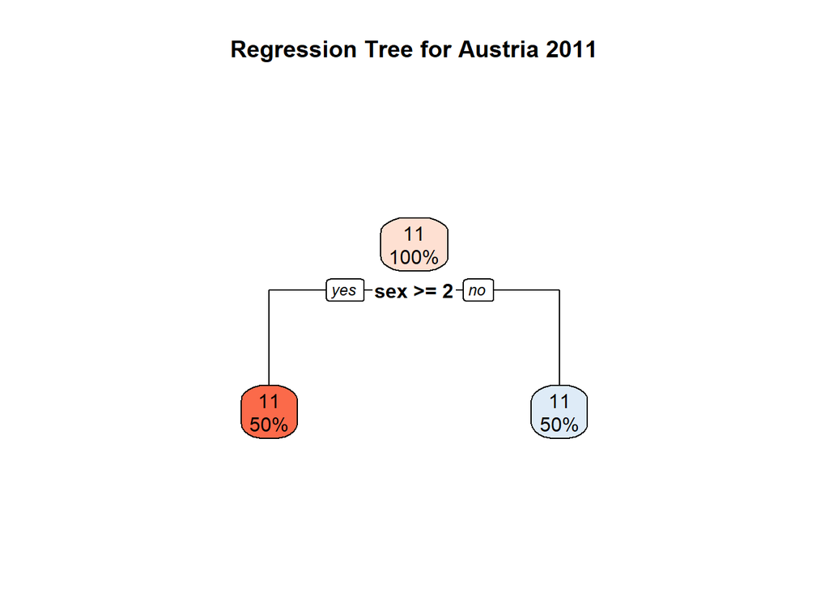

```r
rpart.plot(AT_tree, box.palette="RdBu", nn=FALSE, type=2, main = "Regression Tree for Austria 2011")
```

```r
FR_equality_data <- FR_equality_data %>%
  mutate(train_index = sample(c("train", "test"), nrow(FR_equality_data), replace=TRUE, prob=c(0.67, 0.33)))

FR_train <- FR_equality_data %>% filter(train_index=="train")
FR_test <- FR_equality_data %>% filter(train_index=="test")


FR_tree <- rpart(formula, data = FR_train, cp=.003)

FR_tree
```

```
## n= 7348
##
## node), split, n, deviance, yval
##       * denotes terminal node
##
## 1) root 7348 5852.9600 10.72465
##   2) sex>=1.5 3766 3520.8540 10.66340 *
##   3) sex< 1.5 3582 2303.1310 10.78903
##     6) father_edu< 1.5 3090 2068.1160 10.75670 *
##     7) father_edu>=1.5 492  211.4952 10.99211 *
```

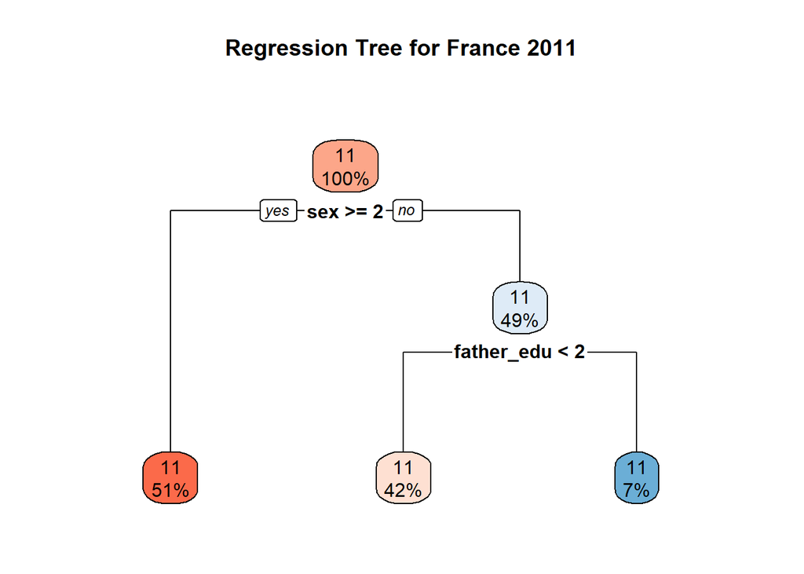

```r
rpart.plot(FR_tree, box.palette="RdBu", nn=FALSE, type=2, main = "Regression Tree for France 2011")
```

```r
ES_equality_data <- ES_equality_data %>%
  mutate(train_index = sample(c("train", "test"), nrow(ES_equality_data), replace=TRUE, prob=c(0.67, 0.33)))

ES_train <- ES_equality_data %>% filter(train_index=="train")
ES_test <- ES_equality_data %>% filter(train_index=="test")


ES_tree <- rpart(formula, data = ES_train, cp=.003)

ES_tree
```

```
## n=11504 (60 observations deleted due to missingness)
##
## node), split, n, deviance, yval
##       * denotes terminal node
##
## 1) root 11504 20621.54 10.28816 *
```

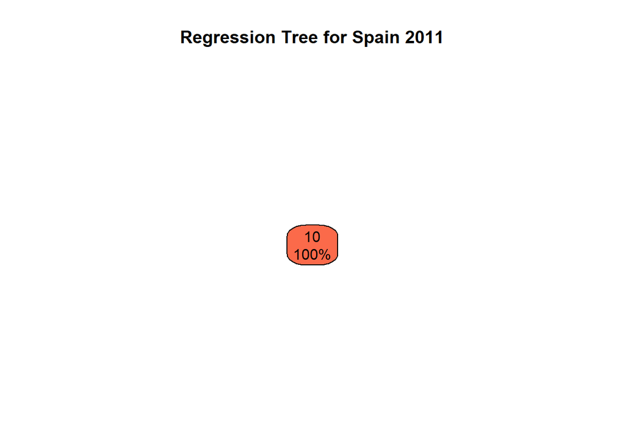

```r
rpart.plot(ES_tree, box.palette="RdBu", nn=FALSE, type=2, main = "Regression Tree for Spain 2011")
```

```r
DK_equality_data <- DK_equality_data %>%
  mutate(train_index = sample(c("train", "test"), nrow(DK_equality_data), replace=TRUE, prob=c(0.67, 0.33)))

DK_train <- DK_equality_data %>% filter(train_index=="train")
DK_test <- DK_equality_data %>% filter(train_index=="test")


DK_tree <- rpart(formula, data = DK_train, cp=.003)

DK_tree
```

```
## n=3061 (24 observations deleted due to missingness)
##
## node), split, n, deviance, yval
##       * denotes terminal node
##
## 1) root 3061 1395.174 11.15718 *
```

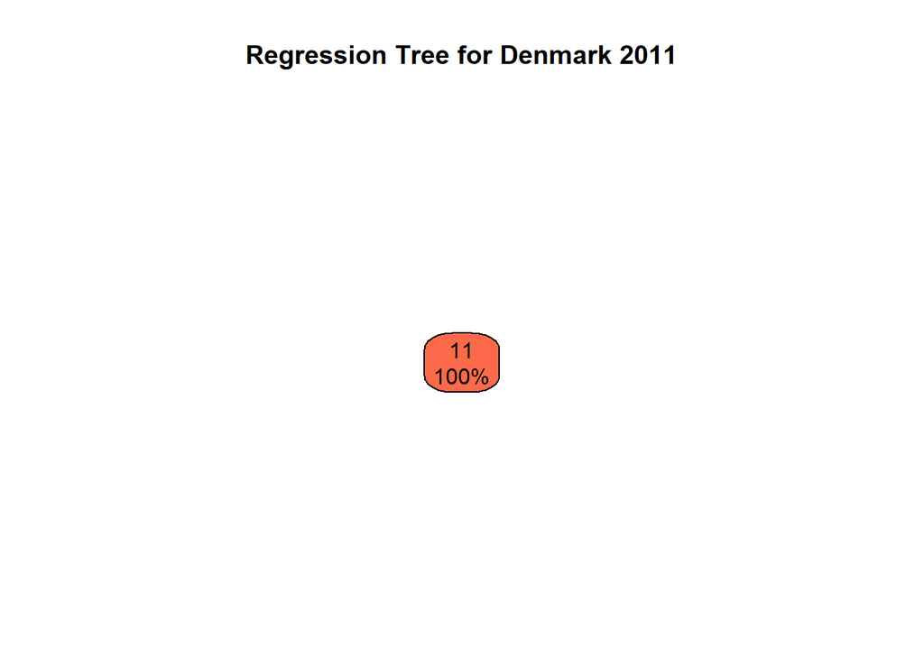

```r
rpart.plot(DK_tree, box.palette="RdBu", nn=FALSE, type=2, main = "Regression Tree for Denmark 2011")
```

```r
IT_equality_data <- IT_equality_data %>%
  mutate(train_index = sample(c("train", "test"), nrow(IT_equality_data), replace=TRUE, prob=c(0.67, 0.33)))

IT_train <- IT_equality_data %>% filter(train_index=="train")
IT_test <- IT_equality_data %>% filter(train_index=="test")


IT_tree <- rpart(formula, data = IT_train, cp=.003)

IT_tree
```

```
## n= 25540
##
## node), split, n, deviance, yval
##       * denotes terminal node
##
## 1) root 25540 32118.68 16.67441
##   2) sex>=1.5 12576 14422.10 16.59351 *
##   3) sex< 1.5 12964 17534.41 16.75289 *
```

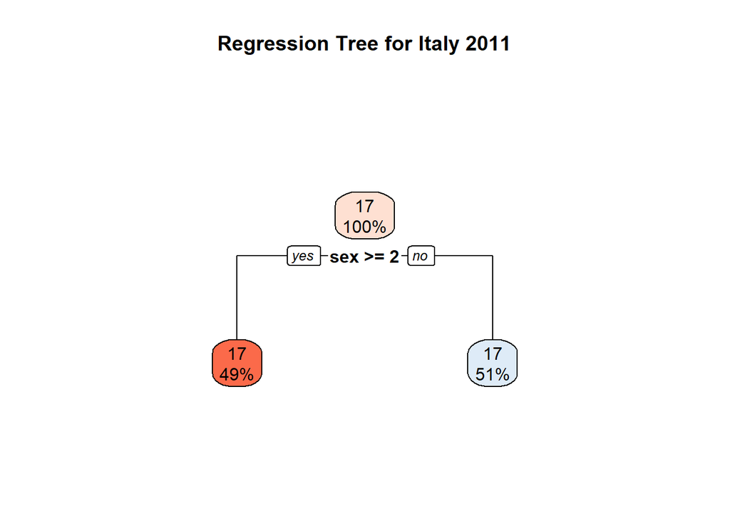

```r
rpart.plot(IT_tree, box.palette="RdBu", nn=FALSE, type=2, main = "Regression Tree for Italy 2011")
```

```r
FI_equality_data <- FI_equality_data %>%
  mutate(train_index = sample(c("train", "test"), nrow(FI_equality_data), replace=TRUE, prob=c(0.67, 0.33)))

FI_train <- FI_equality_data %>% filter(train_index=="train")
FI_test <- FI_equality_data %>% filter(train_index=="test")


FI_tree <- rpart(formula, data = FI_train, cp=.003)

FI_tree
```

```
## n=5612 (4 observations deleted due to missingness)
##
## node), split, n, deviance, yval
##       * denotes terminal node
##
## 1) root 5612 4221.345 10.81804 *
```

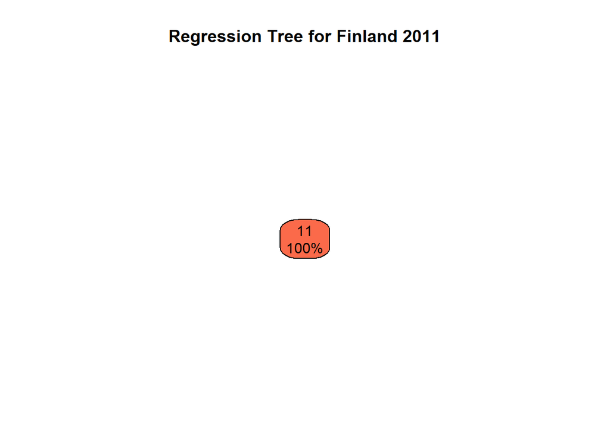

```r
rpart.plot(FI_tree, box.palette="RdBu", nn=FALSE, type=2, main = "Regression Tree for Finland 2011")
```

```r
LV_equality_data <- LV_equality_data %>%
  mutate(train_index = sample(c("train", "test"), nrow(LV_equality_data), replace=TRUE, prob=c(0.67, 0.33)))

LV_train <- LV_equality_data %>% filter(train_index=="train")
LV_test <- LV_equality_data %>% filter(train_index=="test")


LV_tree <- rpart(formula, data = LV_train, cp=.003)

LV_tree
```

```
## n= 4851
##
## node), split, n, deviance, yval
##       * denotes terminal node
##
## 1) root 4851 9915.431 9.168963
##   2) mother_occup>=4.5 3640 8286.543 9.068246 *
##   3) mother_occup< 4.5 1211 1480.978 9.471696 *
```

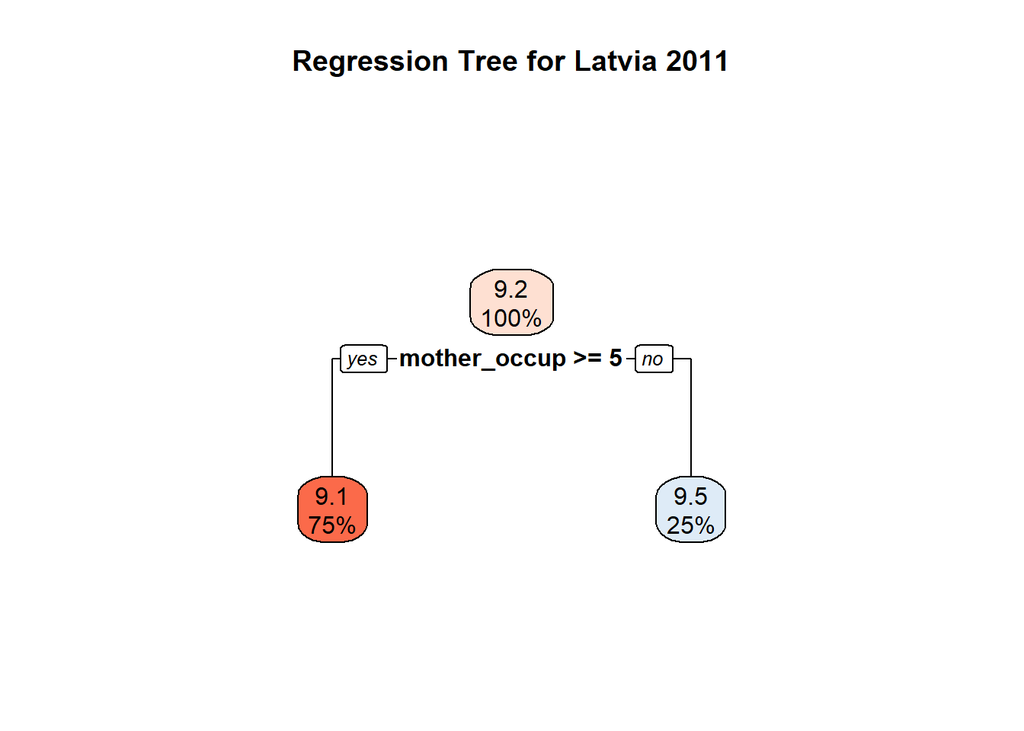

```r
rpart.plot(LV_tree, box.palette="RdBu", nn=FALSE, type=2, main = "Regression Tree for Latvia 2011")
```

# **Conditional Inference Trees**

```r
AT_Ctree <- ctree(formula, data = AT_train)
AT_Ctree
```

```
##
## Model formula:
## log_income ~ sex + parents_present + adults_home + children_home +
##     father_cob + father_cit + mother_cob + mother_cit + father_edu +
##     mother_edu + father_occup_stat + mother_occup_stat + father_occup +
##     mother_occup + father_manag + mother_manag + tenancy
##
## Fitted party:
## [1] root
## |   [2] mother_cob <= 1
## |   |   [3] sex <= 1
## |   |   |   [4] father_edu <= 1: 10.932 (n = 697, err = 628.9)
## |   |   |   [5] father_edu > 1: 11.051 (n = 1079, err = 631.2)
## |   |   [6] sex > 1
## |   |   |   [7] mother_cit <= 2: 10.842 (n = 1514, err = 2235.1)
## |   |   |   [8] mother_cit > 2: 10.566 (n = 223, err = 621.0)
## |   [9] mother_cob > 1
## |   |   [10] sex <= 1
## |   |   |   [11] children_home <= 5
## |   |   |   |   [12] mother_cob <= 2: 11.046 (n = 204, err = 101.4)
## |   |   |   |   [13] mother_cob > 2
## |   |   |   |   |   [14] father_edu <= 1: 10.706 (n = 105, err = 122.6)
## |   |   |   |   |   [15] father_edu > 1
## |   |   |   |   |   |   [16] mother_cit <= 2
## |   |   |   |   |   |   |   [17] mother_manag <= 1: 10.361 (n = 24, err = 128.7)
## |   |   |   |   |   |   |   [18] mother_manag > 1: 10.956 (n = 111, err = 43.0)
## |   |   |   |   |   |   [19] mother_cit > 2: 10.600 (n = 13, err = 9.6)
## |   |   |   [20] children_home > 5: 10.100 (n = 19, err = 115.2)
## |   |   [21] sex > 1: 10.564 (n = 547, err = 1230.6)
##
## Number of inner nodes:    10
## Number of terminal nodes: 11
```

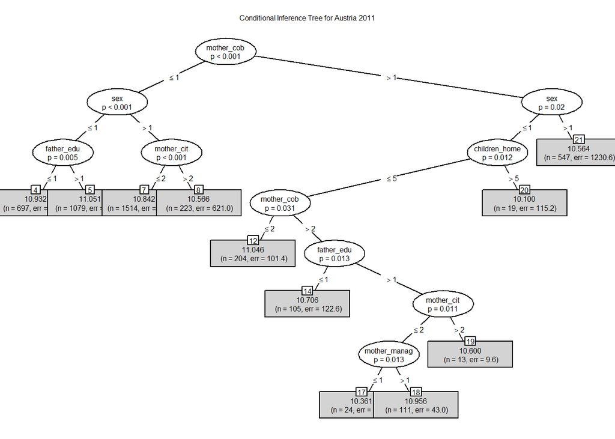

```r
plot(AT_Ctree, type = "simple",gp = gpar(fontsize = 6),
  inner_panel=node_inner,
  ip_args=list(abbreviate = FALSE,id = FALSE), main = "Conditional Inference Tree for Austria 2011")
```

*Cross Validation using the Caret package*

```r
fitControl <- trainControl(method = "repeatedcv", number = 10, repeats = 10, savePredictions = T)
```

```r
AT_cctree1 <- train(formula, data = AT_train, method = "ctree", trControl = fitControl, na.action = na.pass)

AT_cctree1 #This is the suggested tree we get from applying Caret
```

```
## Conditional Inference Tree
##
## 4536 samples
##   17 predictor
##
## No pre-processing
## Resampling: Cross-Validated (10 fold, repeated 10 times)
## Summary of sample sizes: 4082, 4083, 4084, 4083, 4082, 4083, ...
## Resampling results across tuning parameters:
##
##   mincriterion  RMSE      Rsquared     MAE
##   0.01          1.165198  0.007522094  0.7112571
##   0.50          1.145303  0.008005095  0.6889176
##   0.99          1.138132  0.011057196  0.6829340
##
## RMSE was used to select the optimal model using the smallest value.
## The final value used for the model was mincriterion = 0.99.
```

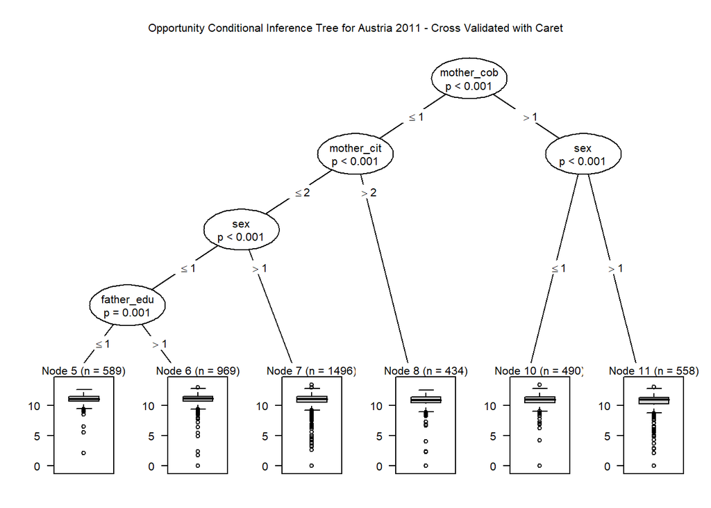

```r
AT_cct <- ctree(formula, data = AT_train, mincriterion = 0.99) #Using the suggestion we generate a Conditional Inference Tree and plot it as our final result

plot(AT_cct,gp = gpar(fontsize = 8),
  inner_panel=node_inner,
  ip_args=list(abbreviate = FALSE,id = FALSE), main = "Opportunity Conditional Inference Tree for Austria 2011 - Cross Validated with Caret")
```

```r
AT_ctree2 <- ctree(formula, data = AT_equality_data, control = ctree_control(testtype = "Bonferroni", mincriterion = 0.99))
AT_ctree2
```

```
##
## Model formula:
## log_income ~ sex + parents_present + adults_home + children_home +
##     father_cob + father_cit + mother_cob + mother_cit + father_edu +
##     mother_edu + father_occup_stat + mother_occup_stat + father_occup +
##     mother_occup + father_manag + mother_manag + tenancy
##
## Fitted party:
## [1] root
## |   [2] sex <= 1
## |   |   [3] mother_cob <= 2
## |   |   |   [4] father_edu <= 0: 10.803 (n = 101, err = 234.8)
## |   |   |   [5] father_edu > 0
## |   |   |   |   [6] mother_cit <= 2
## |   |   |   |   |   [7] father_cit <= 2
## |   |   |   |   |   |   [8] mother_edu <= 1: 11.020 (n = 1301, err = 909.8)
## |   |   |   |   |   |   [9] mother_edu > 1: 11.109 (n = 1011, err = 634.3)
## |   |   |   |   |   [10] father_cit > 2: 10.925 (n = 260, err = 172.8)
## |   |   |   |   [11] mother_cit > 2: 10.891 (n = 278, err = 169.6)
## |   |   [12] mother_cob > 2
## |   |   |   [13] children_home <= 5: 10.788 (n = 357, err = 339.7)
## |   |   |   [14] children_home > 5: 9.958 (n = 12, err = 113.2)
## |   [15] sex > 1
## |   |   [16] mother_cob <= 1
## |   |   |   [17] mother_cit <= 1
## |   |   |   |   [18] father_cit <= 2: 10.867 (n = 1679, err = 2193.3)
## |   |   |   |   [19] father_cit > 2: 10.777 (n = 306, err = 409.7)
## |   |   |   [20] mother_cit > 1: 10.742 (n = 545, err = 853.7)
## |   |   [21] mother_cob > 1: 10.593 (n = 891, err = 2137.9)
##
## Number of inner nodes:    10
## Number of terminal nodes: 11
```

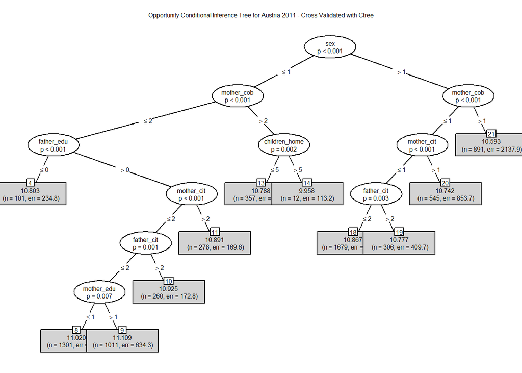

```r
plot(AT_ctree2, type = "simple",gp = gpar(fontsize = 6),
  inner_panel=node_inner,
  ip_args=list(abbreviate = FALSE,id = FALSE), main = "Opportunity Conditional Inference Tree for Austria 2011 - Cross Validated with Ctree")
```

```r
AT_test$P_AtCt <- predict(AT_ctree2, newdata = as.data.frame(AT_test))

AT_test$perror <- (AT_test$P_AtCt - AT_test$log_income)^2

AT_test$RMSE <- sqrt(sum((AT_test$P_AtCt - AT_test$log_income)^2/nrow(AT_test), na.rm = T))

# For Austria we have a RMSE of 1.2, which is not very good. But is most likely attributed to the synthetic data.

# Plot the Errors somehow
```

```r
FR_Ctree <- ctree(formula, data = FR_train)
FR_Ctree
```

```
##
## Model formula:
## log_income ~ sex + parents_present + adults_home + children_home +
##     father_cob + father_cit + mother_cob + mother_cit + father_edu +
##     mother_edu + father_occup_stat + mother_occup_stat + father_occup +
##     mother_occup + father_manag + mother_manag + tenancy
##
## Fitted party:
## [1] root
## |   [2] sex <= 1
## |   |   [3] father_edu <= 1
## |   |   |   [4] mother_cit <= 1: 10.777 (n = 2543, err = 1660.3)
## |   |   |   [5] mother_cit > 1: 10.690 (n = 288, err = 168.2)
## |   |   [6] father_edu > 1: 10.868 (n = 751, err = 466.8)
## |   [7] sex > 1
## |   |   [8] tenancy <= 1
## |   |   |   [9] mother_cit <= 2: 10.697 (n = 2183, err = 1924.0)
## |   |   |   [10] mother_cit > 2: 10.607 (n = 171, err = 146.2)
## |   |   [11] tenancy > 1
## |   |   |   [12] father_cit <= 1: 10.647 (n = 1203, err = 1174.1)
## |   |   |   [13] father_cit > 1: 10.452 (n = 209, err = 263.9)
##
## Number of inner nodes:    6
## Number of terminal nodes: 7
```

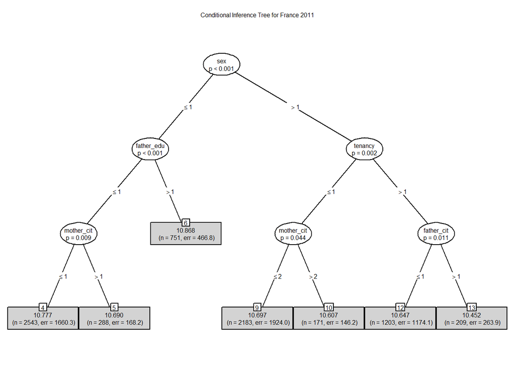

```r
plot(FR_Ctree, type = "simple",gp = gpar(fontsize = 6),
  inner_panel=node_inner,
  ip_args=list(abbreviate = FALSE,id = FALSE), main = "Conditional Inference Tree for France 2011")
```

```r
FR_cctree <- train(formula, data = FR_train, method = "ctree", trControl = fitControl, na.action = na.pass)

FR_cctree #This is the suggested tree we get from applying Caret
```

```
## Conditional Inference Tree
##
## 7348 samples
##   17 predictor
##
## No pre-processing
## Resampling: Cross-Validated (10 fold, repeated 10 times)
## Summary of sample sizes: 6612, 6615, 6613, 6615, 6613, 6612, ...
## Resampling results across tuning parameters:
##
##   mincriterion  RMSE       Rsquared     MAE
##   0.01          0.8969202  0.008025817  0.5931404
##   0.50          0.8893252  0.006947776  0.5815613
##   0.99          0.8872471  0.008028844  0.5785668
##
## RMSE was used to select the optimal model using the smallest value.
## The final value used for the model was mincriterion = 0.99.
```

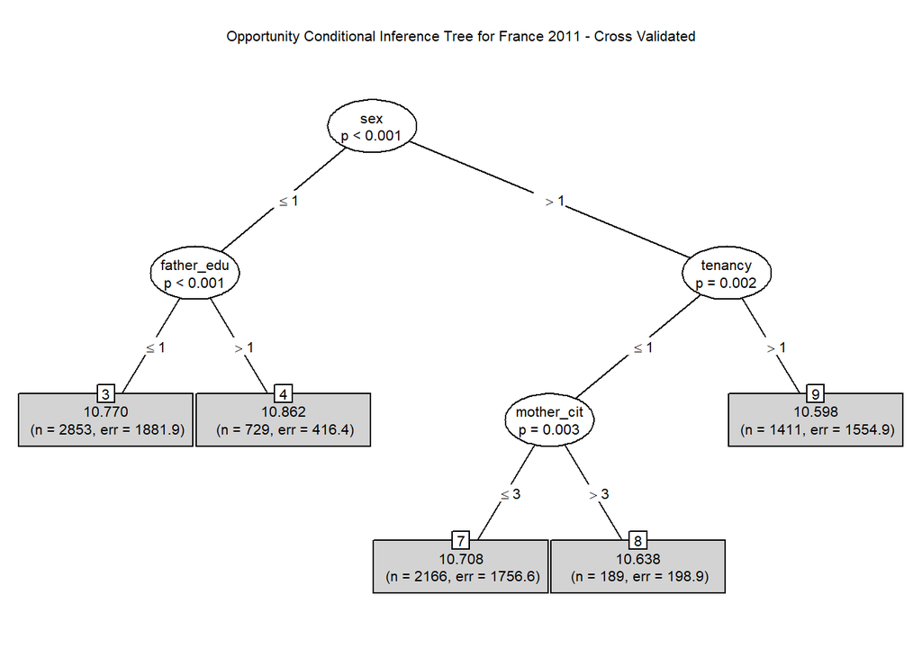

```r
FR_cct <- ctree(formula, data = FR_train, mincriterion = 0.99) #Using the suggestion we generate a Conditional Inference Tree and plot it as our final result

plot(FR_cct, type = "simple",gp = gpar(fontsize = 8),
  inner_panel=node_inner,
  ip_args=list(abbreviate = FALSE,id = FALSE), main = "Opportunity Conditional Inference Tree for France 2011 - Cross Validated")
```

```r
FR_test$P_FRCt <- predict(FR_cct, newdata = as.data.frame(FR_test))

FR_test$perror <- (FR_test$P_FRCt - FR_test$log_income)^2

FR_test$RMSE <- sqrt(sum((FR_test$P_FRCt - FR_test$log_income)^2/nrow(FR_test), na.rm = T))

# RMSE 0.8
```

```r
ES_Ctree <- ctree(formula, data = ES_train)
ES_Ctree
```

```
##
## Model formula:
## log_income ~ sex + parents_present + adults_home + children_home +
##     father_cob + father_cit + mother_cob + mother_cit + father_edu +
##     mother_edu + father_occup_stat + mother_occup_stat + father_occup +
##     mother_occup + father_manag + mother_manag + tenancy
##
## Fitted party:
## [1] root
## |   [2] mother_cit <= 1
## |   |   [3] father_cit <= 1
## |   |   |   [4] sex <= 1
## |   |   |   |   [5] father_cob <= 1
## |   |   |   |   |   [6] father_edu <= 0: 10.273 (n = 268, err = NaN)
## |   |   |   |   |   [7] father_edu > 0: 10.477 (n = 3628, err = NaN)
## |   |   |   |   [8] father_cob > 1: 10.189 (n = 638, err = NaN)
## |   |   |   [9] sex > 1
## |   |   |   |   [10] father_cob <= 1: 10.293 (n = 3396, err = NaN)
## |   |   |   |   [11] father_cob > 1: 10.043 (n = 661, err = NaN)
## |   |   [12] father_cit > 1: 10.157 (n = 1370, err = NaN)
## |   [13] mother_cit > 1: 10.107 (n = 1603, err = NaN)
##
## Number of inner nodes:    6
## Number of terminal nodes: 7
```

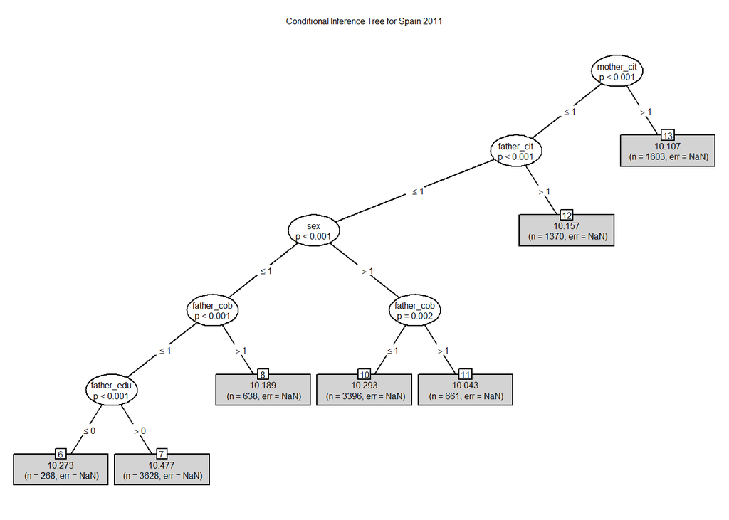

```r
plot(ES_Ctree, type = "simple",gp = gpar(fontsize = 6),
  inner_panel=node_inner,
  ip_args=list(abbreviate = FALSE,id = FALSE), main = "Conditional Inference Tree for Spain 2011")
```

```r
ES_cctree <- train(formula, data = ES_train, method = "ctree", trControl = fitControl, na.action = na.omit) #The spanish synthetic dataset has many NA`s, the output of the tree is unreliable as we don't have information on the errors

ES_cctree #This is the suggested tree we get from applying Caret
```

```
## Conditional Inference Tree
##
## 11564 samples
##    17 predictor
##
## No pre-processing
## Resampling: Cross-Validated (10 fold, repeated 10 times)
## Summary of sample sizes: 6, 6, 6, 6, 6, 6, ...
## Resampling results across tuning parameters:
##
##   mincriterion  RMSE       Rsquared  MAE
##   0.01          0.6213837  NaN       0.6213837
##   0.50          0.6213837  NaN       0.6213837
##   0.99          0.6213837  NaN       0.6213837
##
## RMSE was used to select the optimal model using the smallest value.
## The final value used for the model was mincriterion = 0.99.
```

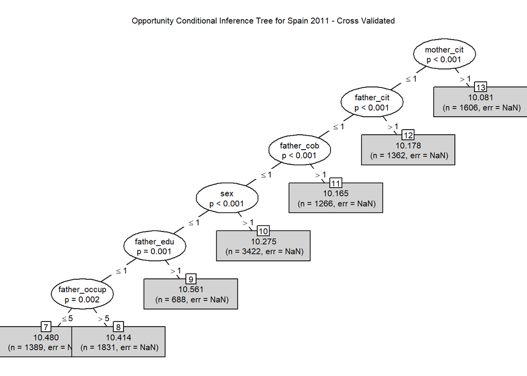

```r
ES_cct <- ctree(formula, data = ES_train, mincriterion = 0.99) #Using the suggestion we generate a Conditional Inference Tree and plot it as our final result

plot(ES_cct, type = "simple",gp = gpar(fontsize = 8),
  inner_panel=node_inner,
  ip_args=list(abbreviate = FALSE,id = FALSE), main = "Opportunity Conditional Inference Tree for Spain 2011 - Cross Validated")
```

```r
IT_Ctree <- ctree(formula, data = IT_train, control = ctree_control())
IT_Ctree
```

```
##
## Model formula:
## log_income ~ sex + parents_present + adults_home + children_home +
##     father_cob + father_cit + mother_cob + mother_cit + father_edu +
##     mother_edu + father_occup_stat + mother_occup_stat + father_occup +
##     mother_occup + father_manag + mother_manag + tenancy
##
## Fitted party:
## [1] root
## |   [2] sex <= 1: 16.753 (n = 12964, err = 17534.4)
## |   [3] sex > 1
## |   |   [4] father_occup <= 7: 16.584 (n = 9419, err = 10565.6)
## |   |   [5] father_occup > 7: 16.623 (n = 3157, err = 3852.8)
##
## Number of inner nodes:    2
## Number of terminal nodes: 3
```

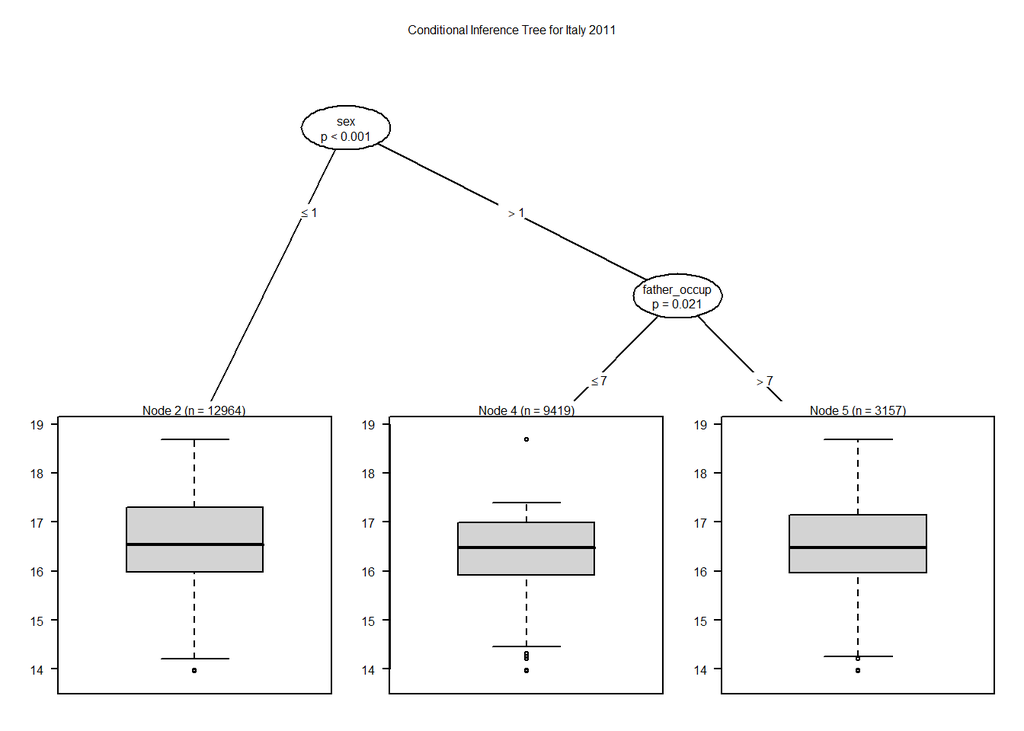

```r
plot(IT_Ctree,gp = gpar(fontsize = 6),
  inner_panel=node_inner,
  ip_args=list(abbreviate = FALSE,id = FALSE), main = "Conditional Inference Tree for Italy 2011")
```

```r
IT_cctree <- train(formula, data = IT_train, method = "ctree", trControl = fitControl, na.action = na.pass)

IT_cctree #suggests using mincriterion 0.99
```

```
## Conditional Inference Tree
##
## 25540 samples
##    17 predictor
##
## No pre-processing
## Resampling: Cross-Validated (10 fold, repeated 10 times)
## Summary of sample sizes: 22986, 22987, 22985, 22986, 22985, 22986, ...
## Resampling results across tuning parameters:
##
##   mincriterion  RMSE      Rsquared     MAE
##   0.01          1.124577  0.001877554  0.8663355
##   0.50          1.118683  0.005242715  0.8606371
##   0.99          1.118639  0.005288233  0.8601645
##
## RMSE was used to select the optimal model using the smallest value.
## The final value used for the model was mincriterion = 0.99.
```

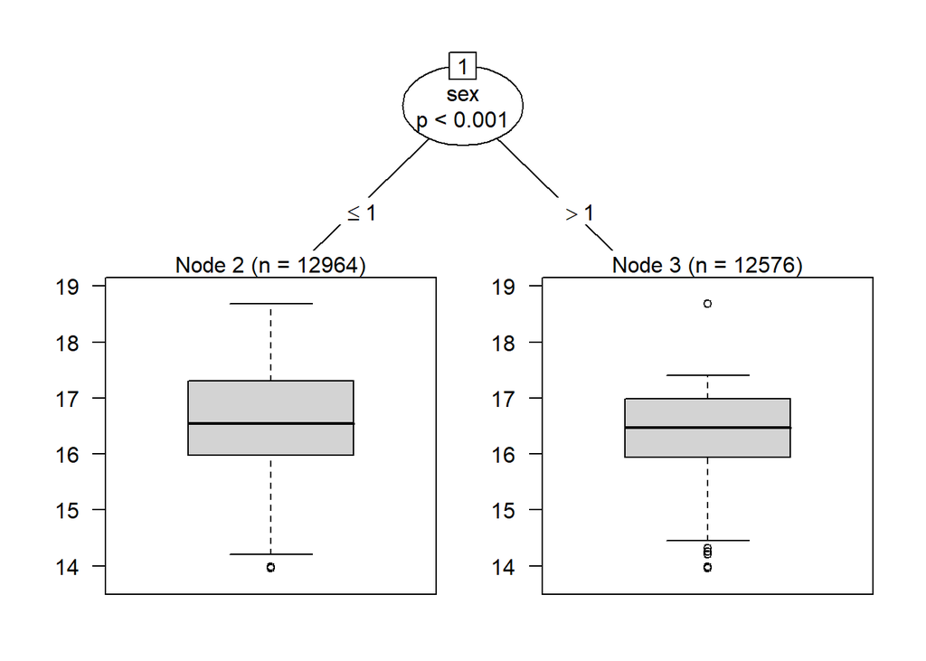

```r
plot(IT_cctree$finalModel)
```

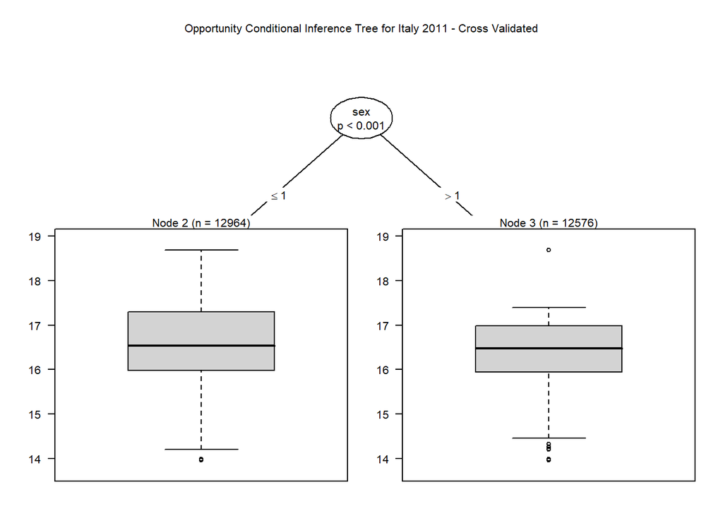

```r
#plotted as ctree
IT_cct <- ctree(formula, data = IT_train, mincriterion = 0.99)

plot(IT_cct,gp = gpar(fontsize = 8),
  inner_panel=node_inner,
  ip_args=list(abbreviate = FALSE,id = FALSE), main = "Opportunity Conditional Inference Tree for Italy 2011 - Cross Validated")
```

```r
#In Italy we have too many NAs among the circumstantial
```

```r
IT_test$P_Ct <- predict(IT_cct, newdata = as.data.frame(IT_test))

IT_test$perror <- (IT_test$P_Ct - IT_test$log_income)^2

IT_test$RMSE <- sqrt(sum((IT_test$P_Ct - IT_test$log_income)^2/nrow(IT_test), na.rm = T))
```

```r
# The Denmark set has too many missing values, we cannot evaluate it with the given variables

DK_cctree <- train(formula, data = DK_train, method = "ctree", trControl = fitControl, na.action = na.omit)
```

```
## Error: Every row has at least one missing value were found
```

```r
DK_cctree
```

[output not shown]

```r
# The Finland set has too many missing values
FI_cctree <- train(formula, data = FI_train, method = "ctree", trControl = fitControl, na.action = na.omit)
```

```
## Error: Every row has at least one missing value were found
```

```r
FI_cctree
```

[output not shown]